# Trace amine-associated receptor 1 (TAAR1) agonists for psychosis - Results from the human studies

### 6.3.15 Anticholinergic symptoms

#### Timepoint 1: *1 day - 2 weeks*

No usable data available from RCT.

#### Timepoint 2: *3 weeks - 13 week*

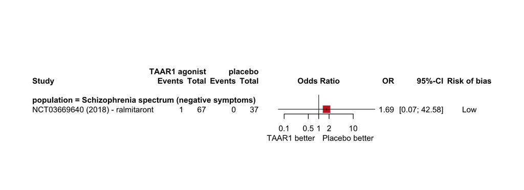

**Figure 82** Forest plot for anticholinergic side-effects (i.e., constipation in this study) for the comparison of adjunctive TAAR1 agonist vs. placebo to antipsychotic treatment at 3-13 weeks. The overall risk of bias of the studies for this outcome is presented. OR=Odds ratio, 95%CI: 95% confidence intervals.

#### Timepoint 3: *> 13 weeks*

No usable data available from RCT.

### 6.3.16 Hypotension

#### Timepoint 1: *1 day - 2 weeks*

No usable data available from RCT.

#### Timepoint 2: *3 weeks - 13 weeks*

No usable data available from RCT.

#### Timepoint 3: *> 13 weeks*

No usable data available from RCT.

### 6.3.17 Dizziness

#### Timepoint 1: *1 day - 2 weeks*

No usable data available from RCT.

#### Timepoint 2: *3 weeks - 13 weeks*

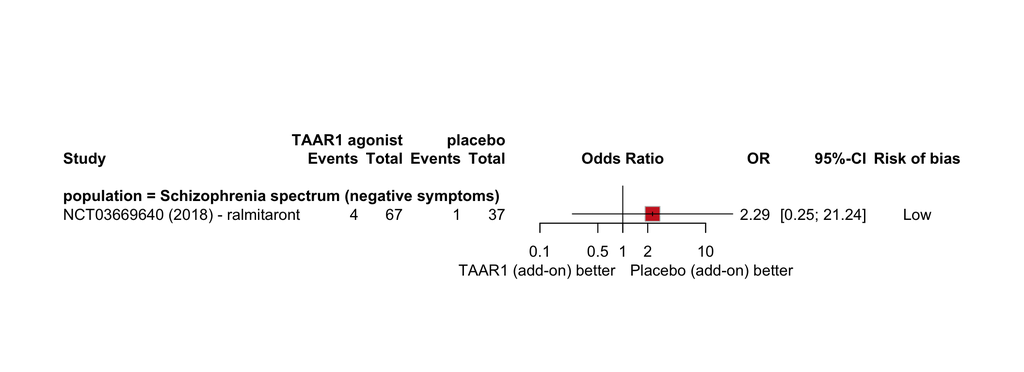

**Figure 83** Forest plot for dizziness for the comparison of adjunctive TAAR1 agonist vs. placebo to antipsychotic treatment at 3-13 weeks (primary timepoint). The overall risk of bias of the studies for this outcome is presented. OR=Odds ratio, 95%CI: 95% confidence intervals.

#### Timepoint 3: *> 13 weeks*

No usable data available from RCT.

### 6.3.18 Nausea or vomiting

#### Timepoint 1: *1 day - 2 weeks*

No usable data available from RCT.

#### Timepoint 2: *3 weeks - 13 weeks*

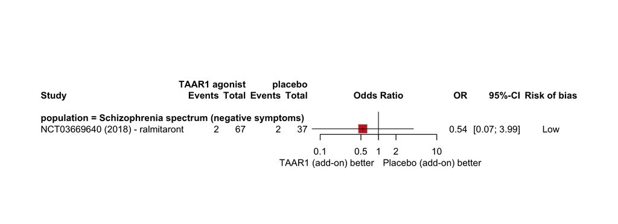

**Figure 84** Forest plot for nausea or vomiting for the comparison of adjunctive TAAR1 agonist vs. placebo to antipsychotic treatment at 3-13 weeks (primary timepoint). The overall risk of bias of the studies for this outcome is presented. OR=Odds ratio, 95%CI: 95% confidence intervals.

#### Timepoint 3: *> 13 weeks*

No usable data available from RCT.

### 6.3.19 QTc prolongation

#### Timepoint 1: *1 day - 2 weeks*

No usable data available from RCT.

#### Timepoint 2: *3 weeks - 13 weeks*

No usable data available from RCT.

#### Timepoint 3: *> 13 weeks*

No usable data available from RCT.

### 6.3.20 QTc interval in msec

#### Timepoint 1: *1 day - 2 weeks*

No usable data available from RCT.

#### Timepoint 2: *3 weeks - 13 weeks*

No usable data available from RCT.

#### Timepoint 3: *> 13 weeks*

No usable data available from RCT.

### 6.3.21 Weight increased

#### Timepoint 1: *1 day - 2 weeks*

No usable data available from RCT.

#### Timepoint 2: *3 weeks - 13 weeks*

No usable data available from RCT.

#### Timepoint 3: *> 13 weeks*

No usable data available from RCT.

### 6.3.22 Weight in kg

#### Timepoint 1: *1 day - 2 weeks*

No usable data available from RCT.

#### Timepoint 2: *3 weeks - 13 weeks*

No usable data available from RCT.

#### Timepoint 3: *> 13 weeks*

No usable data available from RCT.

### 6.3.23 Hyperprolactinemia

#### Timepoint 1: *1 day - 2 weeks*

No usable data available from RCT.

#### Timepoint 2: *3 weeks - 13 weeks*

No usable data available from RCT.

#### Timepoint 3: *> 13 weeks*

No usable data available from RCT.

### 6.3.24 Prolactin levels in ng/ml

#### Timepoint 1: *1 day - 2 weeks*

No usable data available from RCT.

#### Timepoint 2: *3 weeks - 13 weeks*

No usable data available from RCT.

#### Timepoint 3: *> 13 weeks*

No usable data available from RCT.

### 6.3.25 Akathisia

Terms considered included: restlessness (when was used to describe akathisia)

#### Timepoint 1: *1 day - 2 weeks*

No usable data available from RCT.

#### Timepoint 2: *3 weeks - 13 weeks*

No usable data available from RCT.

#### Timepoint 3: *> 13 weeks*

No usable data available from RCT.

### 6.3.26 Extrapyramidal symptoms

#### Timepoint 1: *1 day - 2 weeks*

No usable data available from RCT.

#### Timepoint 2: *3 weeks - 13 weeks*

No usable data available from RCT.

#### Timepoint 3: *> 13 weeks*

No usable data available from RCT.

### 6.3.27 Anxiety

#### Timepoint 1: *1 day - 2 weeks*

No usable data available from RCT.

#### Timepoint 2: *3 weeks - 13 weeks*

No usable data available from RCT.

#### Timepoint 3: *> 13 weeks*

No usable data available from RCT.

### 6.3.28 Agitation

#### Timepoint 1: *1 day - 2 weeks*

No usable data available from RCT.

#### Timepoint 2: *3 weeks - 13 weeks*

No usable data available from RCT.

#### Timepoint 3: *> 13 weeks*

No usable data available from RCT.

### 6.3.29 Headache

#### Timepoint 1: *1 day - 2 weeks*

No usable data available from RCT.

#### Timepoint 2: *3 weeks - 13 weeks*

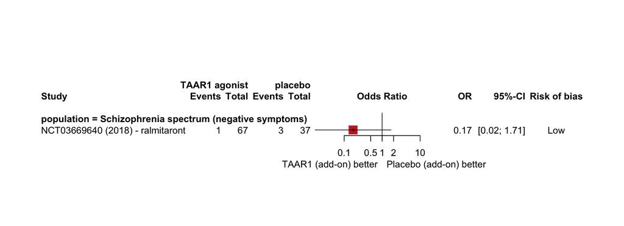

**Figure 85** Forest plot for headache for the comparison of adjunctive TAAR1 agonist vs. placebo to antipsychotic treatment at 3-13 weeks (primary timepoint). The overall risk of bias of the studies for this outcome is presented. OR: Odds ratio, 95%CI: 95% confidence intervals.

#### Timepoint 3: *> 13 weeks*

No usable data available from RCT.

### 6.3.30 Sedation

Terms that were considered as reported in the trials: fatigue, sedation, somnolence.

#### Timepoint 1: *1 day - 2 weeks*

No usable data available from RCT.

#### Timepoint 2: *3 weeks - 13 weeks*

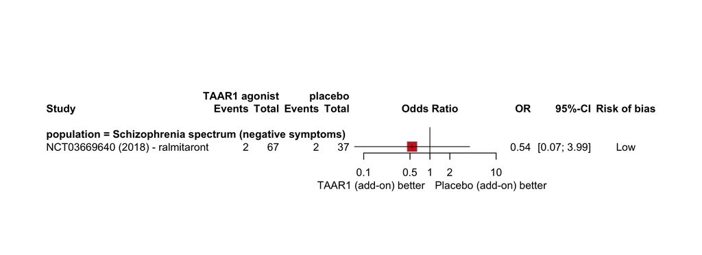

**Figure 86** Forest plot for sedation for the comparison of adjunctive TAAR1 agonist vs. placebo to antipsychotic treatment at 3-13 weeks (primary timepoint). The overall risk of bias of the studies for this outcome is presented. OR: Odds ratio, 95%CI: 95% confidence intervals.

#### Timepoint 3: *> 13 weeks*

No usable data available from RCT.

### 6.3.31 Insomnia

#### Timepoint 1: *1 day - 2 weeks*

No usable data available from RCT.

#### Timepoint 2: *3 weeks - 13 weeks*

There were usable data for one study (Hoffmann-La Roche 2024), which reported 0 events in both groups so that an effect size could not be estimated with the current approach.

#### Timepoint 3: *> 13 weeks*

No usable data available from RCT.

### 6.3.32 Summary outcome plots

#### Efficacy outcomes

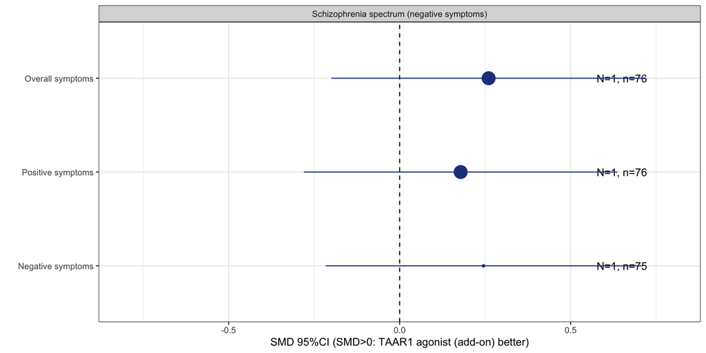

**Figure 87** Summary plot for efficacy outcomes at 12 weeks for the comparison of adjunctive TAAR1 agonists vs. placebo to antipsychotic treatment in adults with schizophrenia and negative symptoms. There were only available data for the timepoint of 3-13 weeks. The size of the points are proportional to the number of participants used in the analysis. SMD>0 correspond to more symptom improvement by TAAR1 agonists compared to placebo. SMD: Standardized mean difference, 95%CI: 95% confidence interval. N=number of studies, n=number of participants.

It should be noted that there were also data for relapse that are not displayed in this figure (see instead 2.7.9).

#### Dropouts and side-effects

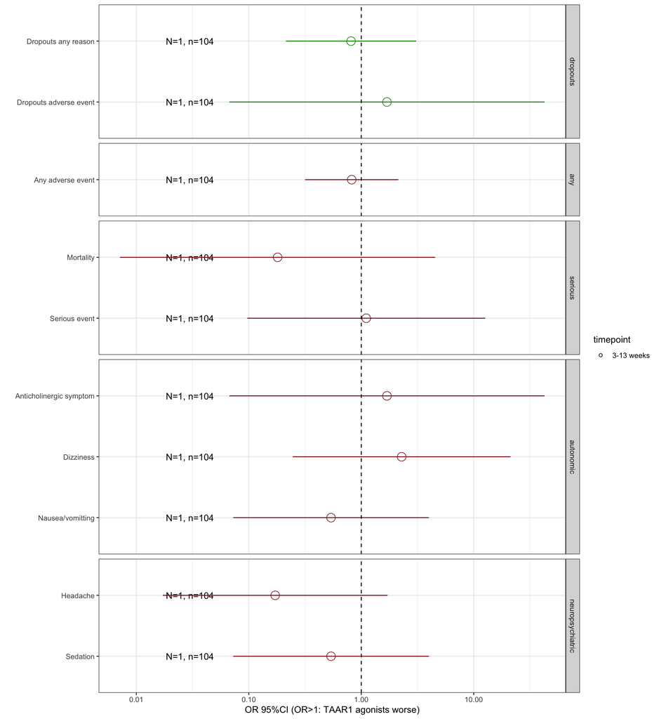

**Figure 88** Summary forest plot for dropouts and side-effects for the comparison of adjunctive TAAR1 agonists vs. placebo to antipsychtoic treatment and for the timepoint of 3-13 weeks. There were available data from a single study including adults with schizophrenia and negative symptoms. The size is proportional to the number of participants in the analysis. OR>1 corresponds to more events with TAAR1 agonists compared to placebo. OR: Odds ratio, 95%CI: 95% confidence intervals. N=number of studies, n=number of participants.

# 7. Mechanistic insights into the effects of TAAR1 agonism for psychosis

There were no usable data available from RCTs on neurobiological measures relevant to psychosis and neurotransmitter signalling that could be analyzed as secondary outcomes of this review. Therefore, to be able to provide additional insights into the mechanism of TAAR1 agonism for psychosis, we sought to describe any potentially available data from both controlled and uncontrolled studies, irrespective of whether they have been included or not in the review (see above).

Additional evidence from two neuroimaging studies (Perini et al. 2023; Sumitomo Pharma America 2023a) generally supports the notion that TAAR1 agonists can ameliorate the elevated striatal dopamine synthesis and release capacity that is considered central in the development of symptoms of psychosis (Howes and Shatalina 2022).

## 7.1 Evidence from functional neuroimaging

Perini et al. (2023) was double-blind, three-arm parallel RCT examining the effects of a single dose of ulotaront 50mg compared to placebo and amisulpride 400mg on fMRI blood oxygen level-dependent (BOLD) striatal responses to reward processing, as measured during the anticipation phase of the Monetary Incentive Delay (MID) task (primary outcome). BOLD striatal responses to reward during the anticipatory phase of MID were selected as the primary outcome due to their potential relation to increased dopamine release in the striatum. The study enrolled 96 healthy volunteers, 51 with low schizotypy traits and 45 with high, as measured with the Schizotypal Personality Questionnaire (scores <10 indicate low schizotypy traits, >=40 high schizotypy traits) to examine interactions due to the potential shared increased striatal activity between positive symptoms and schizotypal traits. The interventions were administered 2 hours before the fMRI. Moreover, the study measured responses to other brain regions, the outcome phase of MID, BOLD responses to the N-back task for working memory, responses to an emotional test battery, resting state connectivity, and arterial spin labelling.

The findings of the primary outcome of this study are reported here as they were deemed most relevant to dopaminergic signalling:

- Ulotaront appeared to be associated with smaller BOLD striatal responses compared to placebo (left striatum: -0.13%, p=0.03, SMD=-0.55, 95%CI: -1.05, -0.05; right striatum: -0.12%, p=0.06, SMD=-0.44, 95%CI: -0.94, 0.06) but not to amisulpride (left: -0.07%, p=0.38, SMD=-0.22, 95%CI: -0.71, 0.27; right: -0.03%, p=0.66, SMD: -0.11, 95%CI: -0.60, 0.38) in the anticipation of loss, and did not differ from both placebo (left: -0.07%, p=0.30, SMD=-0.25, 95%CI: -0.75, 0.25; right: -0.07%, p=0.27, SMD=-0.25, 95%CI: -0.75, 0.25) and amisulpride (left: -0.03%, p=0.65, SMD=-0.11, 95%CI: -0.60, 0.38; right: -0.02%, p=0.74, SMD=-0.08, 95%CI: -0.57, 0.41) in the anticipation of win in the MID task.
- There were no differences in BOLD insular responses (anticipation of loss - ulotaront vs. placebo left 0.00%, p=0.99, SMD=0.00, 95%CI: -0.50, 0.50 and right -0.10%, p=0.16 SMD=-0.36, 95%CI:-0.86, 0.14. ulotaront vs. amisulpride left 0.01%, p=0.94, SMD=0.02, 95%CI: -0.48, 0.52 and right -0.08%, p=0.42, SMD=-0.20, 95%CI: -0.70, 0.30; anticipation of win - ulotaront vs. placebo left: 0.08%, p=0.18, SMD=0.34, 95%CI: -0.16, 0.84, and right -0.01%, p=0.90, SMD=-0.04, 95%CI: -0.54, 0.46, ulotaront vs. amisulpride left 0.02%, p=0.84, SMD=0.05, 95%CI: -0.45, 0.55, and right 0.03%, p=0.72, SMD=0.09, 95%CI: -0.40, 0.58).
- Ulotaront seemed to increase BOLD responses in the medial orbital frontal cortex in anticipation of loss compared to placebo (left: 0.19%, p=0.07, SMD=0.44, 95%CI: -0.06, 0.94; right: 0.17%, p=0.10, SMD=0.43, 95%CI: -0.07, 0.93) and amisulpride (left: 0.25%, p=0.03, SMD=0.56, 95%CI: 0.06, 1.06; right: 0.22%, p=0.05, SMD=0.50, 95%CI: 0.00, 1.00) and in anticipation of win compared to placebo (left: 0.25%, p=0.01, SMD=0.64, 95%CI: 0.14, 1.14; right: 0.24%, p=0.01, SMD=0.68, 95%CI: 0.18, 1.18), but not clearly to amisulpride (left: 0.10%, p=0.30, SMD=0.26, 95%CI: -0.24, 0.76; right: 0.11%, p=0.19, SMD=0.33, 95%CI: -0.16, 0.82).
- Interactions with schizotypy traits were not reported for the primary outcome, but ulotaront was reported to reverse in comparison to placebo the aberrant increased BOLD response in the right insula observed in participants with high schizotypy traits but not in those with low schizotypy traits.

However, it is unclear if the primary outcome was selected *a priori* or *a posteriori*, as no primary outcome was reported in the registration of the study on clinicaltrials.gov, thus biases due to seletected reported outcomes cannot be excluded. There were also differences between the interventions in some of the other measures, with ulotaront being reported as associated with the modification of signals in brain regions associated with cognitive symptoms in schizophrenia. Moreover, ulotaront was associated with sedation in 60% of the participants, more frequently than placebo (see **Figure 37**) and amisulpride (see **Figure 67**) that impaired reaction times in the tasks but was not correlated with BOLD responses. Nevertheless, the impact of this sedative effect on these findings is unclear.

In conclusion, this study suggests that ulotaront might be able to reduce dopamine release in situations that are increased, like the anticipatory phase of MID, and potentially in psychosis.

## 7.2 Evidence from molecular neuroimaging

Sumitomo Pharma America (2023a) was an open-label single-arm trial examining the effects of a 2-week treatment with ulotaront (50-75mg/d) as an add-on to antipsychotic treatment on dopamine synthesis capacity in clinically stable patients with schizophrenia (an uncontrolled study that was not included in this meta-analysis, with available data from a conference abstract in ACNPC 2024 (“ACNP 62(nd) Annual Meeting: Poster Abstracts P251 - P500” 2023)). This study included 14 men and 5 women (aged 18-45 years, mean age 32.9 years) with clinically stable schizophrenia (DSM-5) on a stable dose of antipsychotics for at least 3 weeks before screening. Three additional patients were enrolled but did not complete the baseline scan, so they were excluded from the study. The patients underwent an F-DOPA PET scan both at baseline and after 2 weeks of treatment with ulotaront (50-75mg/d) as an add-on to antipsychotic treatment. At baseline, the patients had a mean PANSS total score of 79.3 (SD=7.3), PANSS positive subscale of 19.2 (SD=4.6), PANSS Marder positive factor of 24.3 (SD=4.6), and CGI-S of 4.2 (SD=0.6), indicating that the patients had on average symptoms of moderate severity.

After 2 weeks of treatment with add-on ulotaront, there was a decrease in dopamine synthesis capacity in the striatum as indicated by the F-DOPA PET scan by -3.98% from baseline (95% CI: -8.68%, 0.72%), with the 95% CI not excluding the null effect, and the striatal subregions ranging from -3.38% in the associative striatum, -3.89% in the sensorimotor striatum, to -5.79% in the limbic striatum. This reduction was considered to be clinically meaningful, and although it was not correlated with the relative reduction in PANSS total scores (r=0.19, p>0.05), it was correlated with improvements in the PANSS Marder positive factor (r=0.49, p<0.05).

The study can be considered to have a high risk of bias due to the single-arm design, lack of control conditions, and the absence of blinding, yet the measurement of dopamine synthesis capacity can be considered objective.

In conclusion, this study suggests that ulotaront may be able to reduce the dopamine synthesis capacity in clinically stable, but still symptomatic, people with schizophrenia, and the decrease in dopamine synthesis could be associated with the improvement of symptoms.

## 7.3 Other data

No other controlled or uncontrolled study (see *included and excluded studies* in the supplementary files of the review) reported any neurobiological measure. It should be noted that another study, i.e., NCT02699372, consisting of double-blind trials examining single and multiple ascending doses of ralmitaront compared to placebo in healthy volunteers (see *Table 1*), utilized neuropsychological tasks but did not couple them with neuroimaging or other neurobiological measures to provide further insights. There were no usable data for this study for any of the outcomes; only brief and narrative descriptions of the findings of these tasks were available in the study protocol of the ralmitaront acute phase study (Roche 2022). These findings describe that ralmitaront improved reward-related behavioral tasks compared to placebo but lacked additional information.

# 8. Subgroup analyses and meta-regressions

## 8.1. Predefined subgroup analyses and meta-regressions

There were fewer than 5 studies available for the analyses of the primary outcome, precluding the exploration of potential reasons for heterogeneity with subgroup analyses and meta-regressions, such as age, sex, baseline severity, diagnosis and patient subgroups (see 8.2), the type of TAAR1 agonist (see 8.3, 8.4), the dose (see 8.4), and other characteristics of TAAR1 agonists.

## 8.2 Subgroups of participants

We presented the effect sizes in each specific subgroup of participants for all outcomes, but we did not perform a formal subgroup test.

## 8.3 Differences between ulotaront and ralmitaront

We explored potential differences between ulotaront and ralmitaront in improving overall symptoms of acute schizophrenia, but we did not conduct any formal subgroup test due to the limited number of studies.

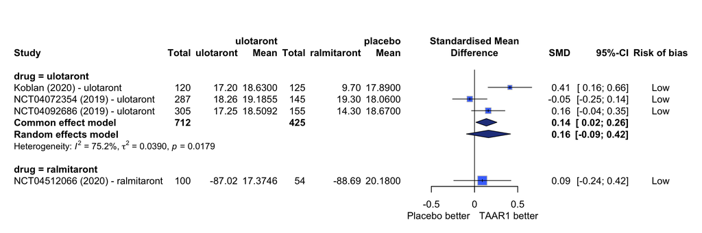

**Figure 89** Forest plot presenting the effects of ulotaront and ralmitaront compared to placebo on overall symptoms in acute schizophrenia (measured with PANSS total) at 4-6 weeks separately. SMD: Standardized mean difference, 95%CI: 95% confidence intervals, SD: standard deviation.

## 8.4 Dose-effect relationships

We explored potential dose-effects by plotting the effect sizes for each fixed-dose level of TAAR1 agonist compared to placebo in improving symptoms in acute schizophrenia (see 8.4.1) or in participants with schizophrenia and predominant negative symptoms (see 8.4.2). However, we did not conduct any formal subgroup test or dose-response meta-analysis due to the limited number of studies

#### 8.4.1 Exploration of dose-efffect of ulotaront and ralmitaront on overall symptoms of acute schizophrenia

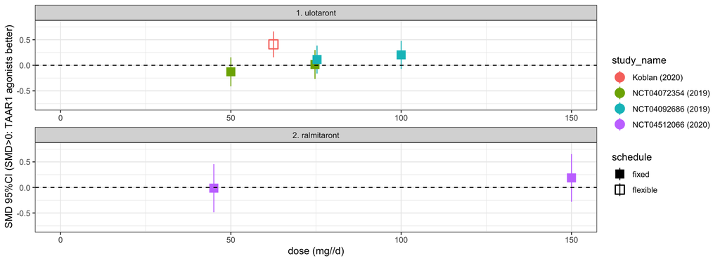

**Figure 90** Effect sizes for each dose level of ulotaront and ralmitaront compared to placebo in improving overall symptoms of acute schizophrenia at 4-6 weeks are presented separately. The findings of each study are presented separately, and the effect sizes were corrected for using the same control condition in each study. It should be noted that Koblan et al. (2020) was a two-arm flexible-dosing study, and its effect size is placed in the middle of the range of the administered dose (50mg/d to 75mg/d). SMD: Standardized mean difference, 95%CI: 95% confidence intervals.

In the fixed-dosing studies (Sumitomo Pharma America 2023b, 2023c; Roche 2022), higher doses (i.e., ulotaront 100mg/d and ralmitaront 150mg/d) may be associated with more improvement compared to smaller doses. However, the effect sizes at these high doses still appear to be small, with a standardized mean difference (SMD) of approximately 0.2. In the flexible dosing study by Koblan et al. (2020) , which utilized doses of ulotaront up to 75mg/d, small-to-medium effect sizes were observed. Importantly, the available data are limited. Moreover, another study (Sumitomo 2024) examined two fixed-doses of ulotaront (50 mg/d and 75 mg/d) compared to placebo, but it is still unpublished with no data available, and it was terminated earlier due to company business strategy. Therefore, dose-effect findings are inconclusive.

#### 8.4.2 Exploration of dose-effects of ralmitaront (monotherapy or add-on to antipsychotics) in people with schizophrenia and predominant negative symptoms

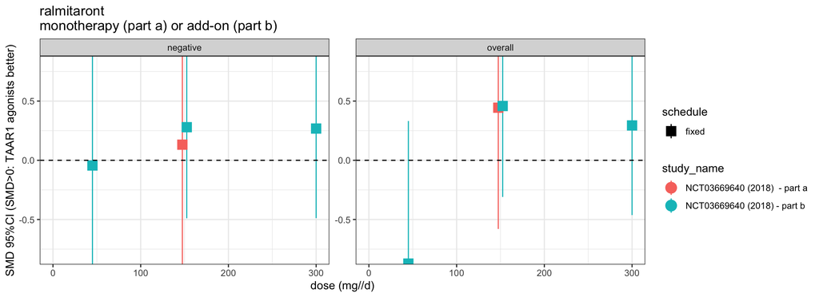

**Figure 91** Effect sizes for each dose level of ralmitaront compared to placebo (monotherapy or add-on to antipsychotic treamtnet) in improving overall symptoms (measured with PANSS total; primary outcome) and negative symptoms (measured with BNSS) in people with schizophrenia or schizoaffective disorder and predominant negative symptoms in at 12 weeks. The findings of each part of the single available study of Hoffmann-La Roche (2024) (part A for monotherapy and part B for add-on treatment) are presented separately, and the effect sizes were corrected for using the same control condition in each study. In this exploratory analysis, we focused on negative symptom scores rather than overall symptoms (primary outcome of the review).

It appeared that ralmitaront 45 mg/d, which was examined as an add-on treatment, resulted potentially in a worsening of overall symptoms and smaller reduction in negative symptoms compared to the higher doses of 150 mg/d and 300 mg/d; this study arm included 5 participants and it was discontinued. The available data were limited, and the findings remained inconclusive.

# 9. Sensitivity analyses

## 9.1. Predefined sensitivity analyses

We did not conduct the following predefined sensitivity analyses for the primary outcome due to the limited data:

1. Restricting the analysis to studies with low risk of bias, since there were 4 studies with low risk of bias in acute schizophrenia (Koblan et al. 2020; Sumitomo Pharma America 2023b, 2023c; Roche 2022), 1 study with high risk of bias in Parkinson’s disease psychosis (1 study with high risk of bias) (Isaacson et al. 2023) and 1 study with high risk of bias in schizophrenia and negative symptoms (Hoffmann-La Roche 2024).
2. Excluding imputed data, since no imputed data were used in the analysis of the primary outcome. There were no imputed data in the analysis of the primary outcome.

## 9.2 Random- and fixed-effects meta-analysis

Due to the limited number of studies, we also presented a fixed-effects model for all outcomes in addition to the random-effects model to assess the robustness of the findings. The findings were robust in the majority of cases. For the primary outcome in the meta-analysis of 4 studies in acute schizophrenia (Koblan et al. 2020; Sumitomo Pharma America 2023b, 2023c; Roche 2022), the point estimate of the effect sizes did not differ between random- and fixed-effects (SMD:0.15 and 0.13, respectively), but the 95% CI in the fixed-effects model was narrower, excluding the null effect (95% CI: -0.05, 0.34, and 0.02, 0.25, respectively). Nonetheless, the interpretation of the findings that TAAR1 agonists have little to no effect compared to placebo in improving overall symptoms does not change

## 9.3 Exploration of the impact of potentially omitted results

This post-hoc sensitivity analysis was conducted to assess whether the inclusion of potentially omitted results would have an impact on the summary effect, especially for the comparison of TAAR1 agonists versus placebo in overall symptoms in acute schizophrenia at 3–13 weeks (see 6.1.1). This was carried out as part of the evaluation of biases due to missing evidence (see 10, 10.1, and 10.4.1).

There were in total 5 completed studies available for this comparison, with 4 presenting data that could be included in the meta-analysis, and one additional study (Sumitomo 2024) that was terminated earlier after the first iteration of this review, enrolling 83 participants (see 10.1). The reason for the termination was company business strategy in clinicaltrials.gov, possibly based on the findings from the previous phase III trials (see 11.1). This study compared two doses of ulotaront (50 mg/day and 75 mg/day) with placebo for over 6 weeks, using a randomized double-blind design and a 1:1:1 ratio. Compared to the other included studies that were conducted in the USA and Europe, this trial was planned to be conducted across multiple sites in East Asia, including mainland China, Taiwan, Japan, and the Philippines.

To assess the potential impact of including the omitted results from this study (sample size of 83 participants, 2:1 ratio of ulotaront to placebo) (Sumitomo 2024) , we assumed a range of point estimates from –0.5 to 0.75. We calculated the corresponding standard error of each effect size based on the assumed point estimate, the total number of participants, and the allocation ratio, and then combined these with the findings from the other studies (see 6.1.1). Subsequently, we plotted the summary effects of these meta-analyses using both random- and fixed-effects models across the range of assumed point estimates for the study with omitted results (Sumitomo 2024) .

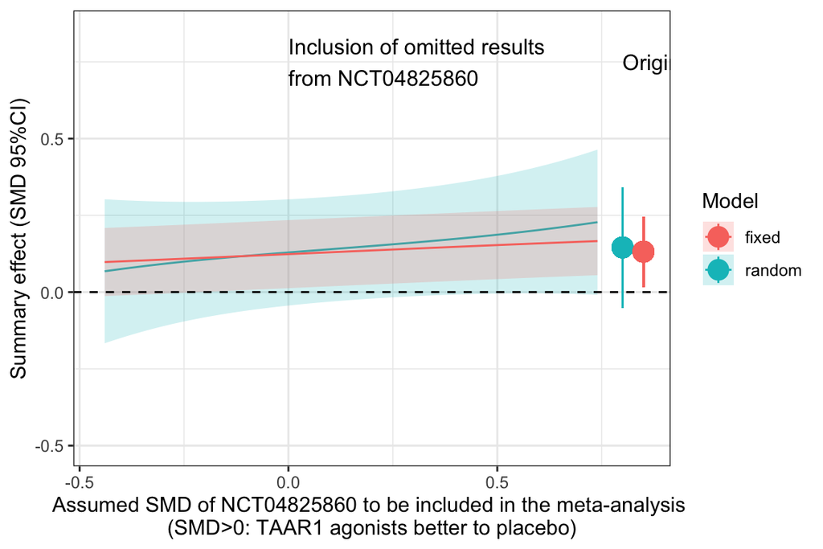

**Figure 92** Exploration of the potential impact of the omitted data from one study with unavailable results on the summary effect of the comparison of TAAR1 agonists vs. placebo on overall symptoms in acute schizophrenia at 3–13 weeks. The x-axis represents the point estimate of the SMD of the omitted results from (Sumitomo 2024). The y-axis represents the summary effects of a meta-analysis including the omitted results across the potential range of assumed effect sizes (from –0.5 to 0.75). The findings from the original meta-analysis without including the omitted results are also presented for comparison. The results from both the random- and fixed-effects models are shown.

It appears that the inclusion of the omitted results from (Sumitomo 2024) would not have materially changed the summary effects in either the random- or fixed-effects meta-analysis. The findings were especially robust within the range of the most plausible effect sizes (e.g., between –0.2 and 0.4), with the point estimates of the meta-analysis falling within the range of trivial to small effects (e.g., between 0.10 and 0.17). Thus, it can be concluded that the omission of the results from (Sumitomo 2024) would not have had a substantial impact on the summary effects of the meta-analysis for this comparison (see 10.4.1).

# 10. Risk of bias due to missing evidence

Risk of bias due to missing evidence was evaluated using the ROB-ME framework (Matthew J. Page et al. 2023), taking into account the usable data from the eligible studies identified through the search, the comprehensiveness of the search strategy, and potential patterns of missing data and small-study effects. We followed the ROB-ME algorithm to assign a judgment of low risk, high risk, or some concerns regarding reporting bias by systematically completing the steps and answering the signalling questions related to the relevant domains.

Specifically, the ROB-ME framework involves four steps in the assessment of reporting biases:

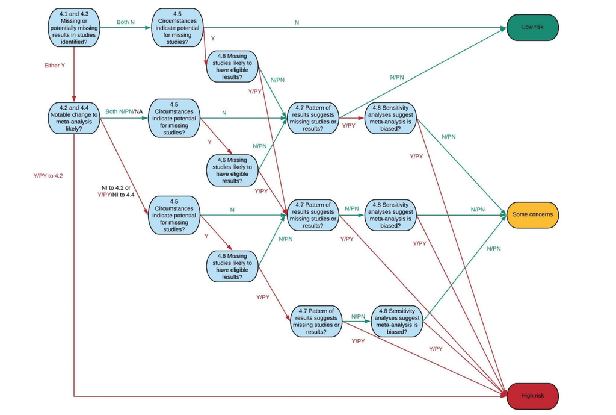

**Figure 93** Algorithm and signalling questions of the fourth step of the ROB-ME framework. This figure was reproduced from the respective cribsheet of ROB-ME, specifically figure 2 available at the link: https://drive.google.com/file/d/1jceuWTo3nbrOrJcGxiXW6naLc32tDsfU/view. No changes were made. The cribsheet and ROB-ME are licensed under [Creative Commons Attribution-NonCommercial-NoDerivatives 4.0 International License.](https://creativecommons.org/licenses/by-nc-nd/4.0/)

## 10.1 Results matrix

We identified the total number of eligible and completed studies, with or without usable data, that could contribute to dropout and safety data for each comparison (as shown in **Table 1** and **Table 2**):

The results matrix for the eligible studies, which were identified in the search, for all outcomes with usable data from at least one study, can be found below in **Table 2**.

| Timepoint | Study name | Population | Age group | Comparison | Sample size | Overall symptoms | Response | Relapse | Positive symptoms | Negative symptoms | Depressive symptoms | Cognitive impairment | Dropouts due to any reason | Dropouts due to adverse events | Any adverse event | Serious adverse event | Mortality due to any cause | Nausea or vomiting | Weight change (kg) | Weight increase (dichotomous) | Prolactin levels (ng/ml) | Prolactin (dichotomous) | Extrapyramidal side-effects | Akathisia | Agitation | Anxiety | Sedation | Insomnia | Headache | … |
| --- | --- | --- | --- | --- | --- | --- | --- | --- | --- | --- | --- | --- | --- | --- | --- | --- | --- | --- | --- | --- | --- | --- | --- | --- | --- | --- | --- | --- | --- | --- |
| 1 day to 2 weeks | Szabo (2023) | Narcolepsy-cataplexy | Adults | TAAR1 agonists vs. placebo | 18 | na | na | na | na | na | na | na | ? (no clearly described under which treatments) | ? (2 patients had dropped out due to nausea, but uclear under which treatment) | ✓ | ✓ | ✓ | ? (4 patients had nausea but uclear under which treatment) | ? (well tolerated, no clinically significant or relevant abnormalities in ECG, blood pressure measurement, laboratory safety parameters) | ? (well tolerated, no clinically significant or relevant abnormalities in ECG, blood pressure measurement, laboratory safety parameters) | ? (no clinically significant findings in laboratory parameters, vital signs, ECG, physical or neurological examinations) | ? (no clinically significant findings in laboratory parameters, vital signs, ECG, physical or neurological examinations) | ? (no clinically significant findings in laboratory parameters, vital signs, ECG, physical or neurological examinations) | ? (no clinically significant findings in laboratory parameters, vital signs, ECG, physical or neurological examinations) | ? (no clinically significant findings in laboratory parameters, vital signs, ECG, physical or neurological examinations) | ? (no clinically significant findings in laboratory parameters, vital signs, ECG, physical or neurological examinations) | ? (2 patients had somnolence but uclear under which treatment) | ? (no clinically significant findings in laboratory parameters, vital signs, ECG, physical or neurological examinations) | ? (no clinically significant findings in laboratory parameters, vital signs, ECG, physical or neurological examinations) | … |
| 1 day to 2 weeks | Koblan et al. 2016 | Schizophrenia (clinically stable) | Adults | TAAR1 agonists vs. placebo | 48 | na | na | na (probably not measured; short trial duration) | na | na | na | na | ? | ? | ? | ? | ? | ? | na | na | ? | ? | ? | ? | ? | ? | ? | ? | ? | … |
| 1 day to 2 weeks | NCT01940159 | Schizophrenia (clinically stable) | Adults | TAAR1 agonists vs. placebo | 48 | na | na | na (probably not measured; short trial duration) | na | na | na | na | ? | ? | ? | ? | ? | ? | na | na | ? | ? | ? | ? | ? | ? | ? | ? | ? | … |
| 1 day to 2 weeks | NCT04325737 | Schizophrenia (clinically stable) | Adults | TAAR1 agonists vs. placebo | 13 | na | na | na | na | na | na | na | ? | ? | ? | ? | ? | ? | na | na | ? | ? | ? | ? | ? | ? | ? | ? | ? | … |
| 1 day to 2 weeks | Tsukada et al. 2023 | Schizophrenia (clinically stable) | Adults | TAAR1 agonists vs. placebo | 68 | na | na | na (probably not measured; short trial duration) | na | na | na | na | ? (no clearly described under which treatments) | ✓ | ✓ | ✓ | ✓ | ✓ | na | na | ? (no changes in vital signs, ulotaront well-tolerated) | ? (no changes in vital signs, ulotaront well-tolerated) | ? (no changes in vital signs, ulotaront well-tolerated) | ? (no changes in vital signs, ulotaront well-tolerated) | ? (no changes in vital signs, ulotaront well-tolerated) | ? (no changes in vital signs, ulotaront well-tolerated) | ✓ | ? (no changes in vital signs, ulotaront well-tolerated) | ? (no changes in vital signs, ulotaront well-tolerated) | … |
| 1 day to 2 weeks | DA801002 (in Galluppi et al. 2021) | Volunteers | Adults | TAAR1 agonists vs. placebo | 16 | na | na | na | na | na | na | na | ? (no information, single dose study focusing on pharmacokinetics) | ? (no information, single dose study focusing on pharmacokinetics) | ? (no information, single dose study focusing on pharmacokinetics) | ? (no information, single dose study focusing on pharmacokinetics) | ? (no information, single dose study focusing on pharmacokinetics) | ? (no information, single dose study focusing on pharmacokinetics) | na | na | ? (no information, single dose study focusing on pharmacokinetics) | ? (no information, single dose study focusing on pharmacokinetics) | ? (no information, single dose study focusing on pharmacokinetics) | ? (no information, single dose study focusing on pharmacokinetics) | ? (no information, single dose study focusing on pharmacokinetics) | ? (no information, single dose study focusing on pharmacokinetics) | ? (no information, single dose study focusing on pharmacokinetics) | ? (no information, single dose study focusing on pharmacokinetics) | ? (no information, single dose study focusing on pharmacokinetics) | … |
| 1 day to 2 weeks | Fowler et al. 2015 | Volunteers | Adults | TAAR1 agonists vs. placebo | 49 | na | na | na | na | na | na | na | ? (reported as well tolerated without relevant findings, no further information) | ? (reported as well tolerated without relevant findings, no further information) | ? (reported as well tolerated without relevant findings, no further information) | ? (no information, single dose study focusing on pharmacokinetics) | ? (no information, single dose study focusing on pharmacokinetics) | ? (no information, single dose study focusing on pharmacokinetics) | na | na | ? (no information, single dose study focusing on pharmacokinetics) | ? (no information, single dose study focusing on pharmacokinetics) | ? (no information, single dose study focusing on pharmacokinetics) | ? (no information, single dose study focusing on pharmacokinetics) | ? (no information, single dose study focusing on pharmacokinetics) | ? (no information, single dose study focusing on pharmacokinetics) | ? (no information, single dose study focusing on pharmacokinetics) | ? (no information, single dose study focusing on pharmacokinetics) | ? (no information, single dose study focusing on pharmacokinetics) | … |
| 1 day to 2 weeks | Hopkins et al. 2021 | Volunteers | Adults | TAAR1 agonists vs. placebo | 24 | na | na | na | na | na | na | na | ✓ | ✓ | ✓ | ✓ | ✓ | ✓ | na | na | ~ (prolactin elevation as dichotomous outcome) | ✓ | ? (reported as generally safe and well tolerated) | ? (reported as generally safe and well tolerated) | ? (reported as generally safe and well tolerated, no changes in vital signs or physical examination) | ? (reported as generally safe and well tolerated, no changes in vital signs or physical examination) | ✓ | ? (reported as generally safe and well tolerated, no changes in vital signs or physical examination) | ? (reported as generally safe and well tolerated, no changes in vital signs or physical examination) | … |
| 1 day to 2 weeks | JapicCTI-194581 | Volunteers | Adults | TAAR1 agonists vs. placebo | 64 | na | na | na | na | na | na | na | ? | ? | ? | ? | ? | ? | na | na | ? | ? | ? | ? | ? | ? | ? | ? | ? | … |
| 1 day to 2 weeks | NCT02699372 | Volunteers | Adults | TAAR1 agonists vs. placebo | 164 | na | na | na | na | na | na | na | ? (well tolerated, no clinically significant or relevant abnormalities in ECG, blood pressure measurement, laboratory safety parameters) | ? (well tolerated, no clinically significant or relevant abnormalities in ECG, blood pressure measurement, laboratory safety parameters) | ? (well tolerated, no clinically significant or relevant abnormalities in ECG, blood pressure measurement, laboratory safety parameters) | ? (well tolerated, no clinically significant or relevant abnormalities in ECG, blood pressure measurement, laboratory safety parameters) | ? (well tolerated, no clinically significant or relevant abnormalities in ECG, blood pressure measurement, laboratory safety parameters) | ? (well tolerated, no clinically significant or relevant abnormalities in ECG, blood pressure measurement, laboratory safety parameters) | ? (well tolerated, no clinically significant or relevant abnormalities in ECG, blood pressure measurement, laboratory safety parameters) | ? (well tolerated, no clinically significant or relevant abnormalities in ECG, blood pressure measurement, laboratory safety parameters) | ? (well tolerated, no clinically significant or relevant abnormalities in ECG, blood pressure measurement, laboratory safety parameters) | ? (well tolerated, no clinically significant or relevant abnormalities in ECG, blood pressure measurement, laboratory safety parameters) | ? (well tolerated, no clinically significant or relevant abnormalities in ECG, blood pressure measurement, laboratory safety parameters) | ? (well tolerated, no clinically significant or relevant abnormalities in ECG, blood pressure measurement, laboratory safety parameters) | ? (well tolerated, no clinically significant or relevant abnormalities in ECG, blood pressure measurement, laboratory safety parameters) | ? (well tolerated, no clinically significant or relevant abnormalities in ECG, blood pressure measurement, laboratory safety parameters) | ? (well tolerated, no clinically significant or relevant abnormalities in ECG, blood pressure measurement, laboratory safety parameters) | ? (well tolerated, no clinically significant or relevant abnormalities in ECG, blood pressure measurement, laboratory safety parameters) | ? (well tolerated, no clinically significant or relevant abnormalities in ECG, blood pressure measurement, laboratory safety parameters) | … |
| 1 day to 2 weeks | SEP361-101 (in Galluppi et al. 2021 and Chen et al. 2022) | Volunteers | Adults | TAAR1 agonists vs. placebo | 52 | na | na | na | na | na | na | na | ? (reported as well tolerated without relevant findings, no further information) | ? (reported as well tolerated without relevant findings, no further information) | ? (reported as well tolerated without relevant findings, no further information) | ? (no information, single dose study focusing on pharmacokinetics) | ? (no information, single dose study focusing on pharmacokinetics) | ? (no information, single dose study focusing on pharmacokinetics) | na | na | ? (no information, single dose study focusing on pharmacokinetics) | ? (no information, single dose study focusing on pharmacokinetics) | ? (no information, single dose study focusing on pharmacokinetics) | ? (no information, single dose study focusing on pharmacokinetics) | ? (no information, single dose study focusing on pharmacokinetics) | ? (no information, single dose study focusing on pharmacokinetics) | ? (no information, single dose study focusing on pharmacokinetics) | ? (no information, single dose study focusing on pharmacokinetics) | ? (no information, single dose study focusing on pharmacokinetics) | … |
| 1 day to 2 weeks | Perini et al. 2023 | Volunteers | Adults | TAAR1 agonists vs. placebo | 69 | na | na | na | na | na | na | na | ✓ | ✓ | ✓ | ✓ | ✓ | ✓ | na | na | ? (no clinically meaningful changes in safety parameters, unclear if measured) | ? (no clinically meaningful changes in safety parameters, unclear if measured) | ? (no clinically meaningful changes in safety parameters) | ? (no clinically meaningful changes in safety parameters) | ? (no clinically meaningful changes in safety parameters) | ? (no clinically meaningful changes in safety parameters) | ✓ | ? (no clinically meaningful changes in safety parameters) | ✓ | … |
| 3-13 weeks | Isaacson et al. 2023 | Parkinson’s disease psychosis | Adults | TAAR1 agonists vs. placebo | 39 | ✓ | ✓ | na (study focusing on acute symptoms) | ✓ | ~ (probably not measured) | ~ (probably not measured) | ✓ | ✓ | ✓ | ✓ | ✓ | ✓ | ✓ | ? (no information, no clinically meaningful changes in ECG, laboratory values) | ? (no information, no clinically meaningful changes in ECG, laboratory values) | ? (no information, no clinically meaningful changes in ECG, laboratory values) | NA | ~ (measured with UPDRS paRT III scale, no differences with placebo) | ~ (measured with UPDRS paRT III scale, no differences with placebo) | ? (neuropsychiatric events seemed to more frequent in ulotaront vs. placebo, including hallucinations and confusational state) | ? (neuropsychiatric events seemed to more frequent in ulotaront vs. placebo, including hallucinations and confusational state) | ✓ | ✓ | ? | … |
| 3-13 weeks | NCT04092686 | Schizophrenia (acute) | Adolescents | TAAR1 agonists vs. placebo | 28 | ? | ? | ? | ? | ? | ? | ? | ? | ? | ? | ? | ? | ? | ? | ? | ? | ? | ? | ? | ? | ? | ? | ? | ? | … |
| 3-13 weeks | Koblan et al. 2020 | Schizophrenia (acute) | Adults | TAAR1 agonists vs. placebo | 245 | ✓ | ✓ | na (study focusing on acute symptoms) | ✓ | ✓ | ✓ | ? (probably not measured at the randomized phase) | ✓ | ✓ | ✓ | ✓ | ✓ | ✓ | ✓ | ✓ | ✓ | ~ (reported as continuous) | ✓ | ✓ | ✓ | ✓ | ✓ | ✓ | ✓ | … |
| 3-13 weeks | NCT04072354 | Schizophrenia (acute) | Adults | TAAR1 agonists vs. placebo | 463 | ✓ | ✓ | na (study focusing on acute symptoms) | X | X | X | ? (probably not measured) | ✓ | ? | ? (no information, NNH for all adverse events >=10) | ? (no information, NNH for all adverse events >=10) | ? (no information, NNH for all adverse events >=10) | ? (no information, NNH for all adverse events >=10) | ? (no information, NNH for all adverse events >=10) | ? (no information, NNH for all adverse events >=10) | ? (no information, NNH for all adverse events >=10) | ? (no information, NNH for all adverse events >=10) | ~ (frequency of extapyramidal side-effects was low and similar to placebo) | < (frequency of extapyramidal side-effects was low and similar to placebo) | ? (no information, NNH for all adverse events >=10) | ? (reported as common, NNH>=10) | NA | ? (reported as common, NNH>=10) | ? (reported as common, NNH>=10) | … |
| 3-13 weeks | NCT04092686 | Schizophrenia (acute) | Adults | TAAR1 agonists vs. placebo | 435 | ✓ | ✓ | na (study focusing on acute symptoms) | X | X | X | ? (probably not measured) | ✓ | ? | ? (no information, NNH for all adverse events >=10) | ? (no information, NNH for all adverse events >=10) | ? (no information, NNH for all adverse events >=10) | ? (no information, NNH for all adverse events >=10) | ? (no information, NNH for all adverse events >=10) | NA | ? (no information, NNH for all adverse events >=10) | ? (no information, NNH for all adverse events >=10) | < (frequency of extapyramidal side-effects was low and similar to placebo) | < (frequency of extapyramidal side-effects was low and similar to placebo) | ? (no information, NNH for all adverse events >=10) | ? (reported as common, NNH>=10) | NA | ? (reported as common, NNH>=10) | ? (reported as common, NNH>=10) | … |
| 3-13 weeks | NCT04825860 | Schizophrenia (acute) | Adults | TAAR1 agonists vs. placebo | 83 | X (study terminated due to buisness strategy, but it is possibly no differences in efficacy outcomes) | X (study terminated due to buisness strategy, but it is possibly no differences in efficacy outcomes) | na (study focusing on acute symptoms) | X (study terminated due to buisness strategy, but it is possibly no differences in efficacy outcomes) | X (study terminated due to buisness strategy, but it is possibly no differences in efficacy outcomes) | X (study terminated due to buisness strategy, but it is possibly no differences in efficacy outcomes) | ? (probably not measured) | ? | ? | ? | ? | ? | ? | ? | ? | ? | ? | ? | ? | ? | ? | ? | ? | ? | … |
| 3-13 weeks | NCT04512066 | Schizophrenia (acute) | Adults | TAAR1 agonists vs. placebo | 213 | ✓ | ✓ | na (study focusing on acute symptoms) | ✓ | ✓ | ✓ | ? | ✓ | ✓ | ✓ | ✓ | ✓ | ✓ | < (reported as dichotomous outcome) | ✓ | ? | ? | ? | ? | ✓ | ✓ | ? | ✓ | ✓ | … |
| 3-13 weeks | NCT05848700 | Schizophrenia (clinically stable) | Adults | TAAR1 agonists vs. placebo | 60 | ? | ? | ? | ? | ? | ? | ? | ? | ? | ? | ? | ? | ? | ? | ? | ? | ? | ? | ? | ? | ? | ? | ? | ? | … |
| 3-13 weeks | NCT03669640 | Schizophrenia (negative symptoms) | Adults | TAAR1 agonists vs. placebo | 27 | ✓ | ✓ | ✓ | ✓ | ✓ | ? | ? (measured according to the protocol, but not reported in the clinicaltrials.gov but reasons are unclear) | ✓ | ✓ | ✓ | ✓ | ✓ | ✓ | ? | ? | ? | ? | < (reported as scale score, no important differences from baseline were noted) | < (reported as scale score, no important differences from baseline were noted) | ? | ? | ✓ | ✓ | ✓ | … |
| 3-13 weeks | NCT03669640 | Schizophrenia (negative symptoms) | Adults | TAAR1 agonists vs. placebo (addon) | 104 | ✓ | ✓ | ✓ | ✓ | ✓ | ? | ? (measured according to the protocol, but not reported in the clinicaltrials.gov but reasons are unclear) | ✓ | ✓ | ✓ | ✓ | ✓ | ✓ | ? | ? | ? | ? | < (reported as scale score, no important differences from baseline were noted) | < (reported as scale score, no important differences from baseline were noted) | ? | ? | ✓ | ✓ | ✓ | … |
| 1 day to 2 weeks | NCT05402111 | Schizophrenia (clinically stable, MetS) | Adults | TAAR1 agonists vs. antipsychotics | 31 | na | na | na (probably not measured; short trial duration) | na | na | na | na | ? (no clearly described under which treatments) | ? | ✓ | ✓ | ✓ | ✓ | na | na | ? (no meaningful change in laboratory values, unclear if prolactin was measured) | ? (no meaningful change in laboratory values, unclear if prolactin was measured) | ? | ? | ? | ? | ✓ | ? | ? | … |
| 1 day to 2 weeks | Perini et al. 2023 | Volunteers | Adults | TAAR1 agonists vs. antipsychotics | 70 | na | na | na | na | na | na | na | ✓ | ✓ | ✓ | ✓ | ✓ | ✓ | na | na | ? (no clinically meaningful changes in safety parameters, unclear if measured) | ? (no clinically meaningful changes in safety parameters, unclear if measured) | ? (no clinically meaningful changes in safety parameters) | ? (no clinically meaningful changes in safety parameters) | ? (no clinically meaningful changes in safety parameters) | ? (no clinically meaningful changes in safety parameters) | ✓ | ? (no clinically meaningful changes in safety parameters) | ✓ | … |
| 3-13 weeks | NCT04512066 | Schizophrenia (acute) | Adults | TAAR1 agonists vs. antipsychotics | 214 | ✓ | ✓ | na (study focusing on acute symptoms) | ✓ | ✓ | ✓ | ? | ✓ | ✓ | ✓ | ✓ | ✓ | ✓ | < (reported as dichotomous outcome) | ✓ | ? | ? | ? | ? | ✓ | ✓ | ? | ✓ | ✓ | … |
| 3-13 weeks | NCT05542264 | Schizophrenia (clinically stable) | Adults | TAAR1 agonists vs. antipsychotics | 19 | ? | ? | ? | ? | ? | ? | ? | ? | ? | ? | ? | ? | ? | ? | ? | ? | ? | ? | ? | ? | ? | ? | ? | ? | … |
| > 13 weeks | NCT04115319 | Schizophrenia (clinically stable) | Adults | TAAR1 agonists vs. antipsychotics | 303 | X (study focusing on tolerability, no significant difference was reported; yet more schizophrenia adverse events) | ? | ✓ (study focusing on tolerability, adverse event: schizophrenia) | X (study focusing on tolerability, no significant difference was reported; yet more schizophrenia adverse events) | X (study focusing on tolerability, no significant difference was reported; yet more schizophrenia adverse events) | ? | ? | ✓ | ✓ | ? | ? | ? | ? | ✓ | ✓ | ~ (no clinically significant findings in prolactin levels) | ~ (no clinically significant findings in prolactin levels) | ? | ? | ? | ✓ | ✓ | ✓ | ? | … |

**Table 2** Results matrix for the primary outcome. ✓: A study result is available for inclusion in the meta-analysis.; ~:No study result is available for inclusion in the meta-analysis, for a reason unrelated to the P value, magnitude or direction of the result.; ?: Unclear whether an eligible study result was generated or unclear reason of missing evidence. Narrative descriptions of the effects of drugs as reported in the studies are mentioned here to facilitate the judgement of regarding the reason of missingness. * Sumitomo Pharma America (2023b) included two parts, i.e., adults (sample size 435) and adolescents (sample size unclear but it was probably 28; planned 90). It should be noted that all of the other studies included adult populations. na: not applicable for this outcome (e.g., efficacy outcomes in healthy volunteers or after a single dose in stable patients).

## 10.2 Funnel plots and examination of small-study effects

There were insufficient data for the primary outcome but also other outcomes (i.e., fewer than 10 studies) to examine small-study effects with funnel plots. Thus, we cannot explore the pattern of missing evidence or conduct sensitivity analysis to explore the potential impact of the missing evidence.

Thus, we replied accordingly to the following signalling questions:

- ROB-ME-4.7 (“*Does the pattern of observed study results suggest that the meta-analysis is likely to be missing results that were systematically different (in terms of P value, magnitude or direction) from those observed?*”) - “probably no”, as no pattern can be observed due to the small number of available studies, but all studies should have been identified.
- ROB-ME-4.8 (“*Did sensitivity analyses suggest that the summary effect estimate was biased due to missing results?*”) - “not applicable”, as no sensitivity analysis was conducted.

## 10.3 Coverage of the search strategy

We conducted a comprehensive search for both published and unpublished studies in multiple electronic databases, supplemented by manual searches of the reference lists of included studies and previous reviews. Screening was carried out by at least two independent reviewers.

Potential limitations of the search strategy:

- All studies identified in the search were conducted by the pharmaceutical industry. Although we contacted them, we have not received additional data for the first and second iteration. Considering that all eligible studies are experimental and were conducted recently, it is expected that most, if not all, have been registered, thus facilitating their detection during searches in clinical trial registries. Nonetheless, it’s possible that small phase I studies focusing on pharmacokinetics may not have been registered and could therefore have been overlooked. Consequently, we do not anticipate that our search has missed any major or significant studies.
- The search strategies used in the first and second iterations of the review were designed to identify studies of newly synthesized drugs with a primary mechanism of action as TAAR1 agonists. However, an increasing number of older drugs have since been identified as TAAR1 agonists, and these were not captured by the current search strategies. Nonetheless, the potential reporting biases associated with these older drugs are likely to stem from different reasons. Therefore, we anticipate that the current assessment, which focuses on newer compounds, would not have been meaningfully affected by this omission of the older compounds.

Thus, we replied accordingly to the following signalling questions:

- ROB-ME-3.1 (“*Were prospectively registered studies or studies identified for a prospective meta-analysis the only type of study eligible for inclusion in the review?*”) - “no”.
- ROB-ME-3.2 (“*Would you expect every eligible study to be identifiable regardless of its results?*”) - “probably yes”.
- ROB-ME-3.3 (“*Were you likely to have found all eligible studies regardless of their results?*”) - “probably yes”.
- ROB-ME-4.5 (“*Do circumstances (identified in Step 3) indicate potential for some eligible studies not being identified because of the P value, magnitude or direction of the results generated?*”) - “no”.

## 10.4 ROB-ME evaluation

### 10.4.1 Reporting bias assessment for efficacy outcomes

We conducted the ROB-ME evaluation for the efficacy outcomes (primary and secondary) by examining the comparisons within each population separately.

#### Primary outcome

The availability of data for the primary outcome varied across comparisons and populations.

For the comparison of *TAAR1 agonists versus placebo as monotherapy in acute schizophrenia,* five studies were eligible: data were available from four studies, while one study, which was terminated early (Sumitomo 2024), did not provide data (see 10.1). A sensitivity analysis found that omitting the findings of the latter study would not have an important impact on the summary of effects (see 9.3).

For the comparisons of *TAAR1 agonists vs. placebo in Parkinson’s disease psychosis, TAAR1 agonists vs. antipsychotics in acute schizophrenia*, and T*AAR1 agonists vs. placebo (as monotherapy or add-on) in participants with schizophrenia and predominant negative symptoms*, one study was eligible for each analysis. Therefore, following a similar approach as described above, a *low risk of reporting bias* was assigned.

#### Secondary efficacy outcomes

For the *comparison of TAAR1 agonists versus placebo*, there were 5 studies eligible as mentioned in 10.4.1. with varied availability in the data for the secondary efficacy outcomes:

- We assigned a *low risk of reporting bias* for the outome of response to treatment similar to the primary outcome of overall symptoms (see 10.4.1).
- The two failed phase III trials(Sumitomo Pharma America 2023b, 2023c) did not report effects on specific symptoms (e.g., positive, negative, and depressive symptoms). It is likely that the inclusion of these omitted results would have impacted the summary estimates, introducing a bias in favor of TAAR1 agonists. Additionally, the prematurely terminated trial (Sumitomo 2024) also lacked available data. Consequently, these analyses are at risk of bias due to missing evidence, and we assigned a high risk of reporting bias (ROB-ME-4.1 “yes”, ROB-ME-4.2 “yes”).

For the comparisons of *TAAR1 agonists vs. placebo in Parkinson’s disease psychosis, TAAR1 agonists vs. antipsychotics in acute schizophrenia*, and T*AAR1 agonists vs. placebo (as monotherapy or add-on) in participants with schizophrenia and predominant negative symptoms*, *TAAR1 agonists vs. antipsychotics in clinically stable schizophrenia (>13 weeks)*, one study was eligible for each analysis. Therefore, following a similar approach as described above, a *low risk of reporting bias* was assigned.

No data were available from eligible studies for other comparisons or for timepoints except 3-13 weeks (except for the cases mentioned above).

### 10.4.2 Reporting bias assessment for the secondary acceptability and tolerability outcomes

We conducted the ROB-ME evaluation for acceptability and tolerability outcomes (i.e., dropouts and side effects) by examining comparisons that pooled the different populations, in accordance with the analyses presented above.

The reasons for missing data on these outcomes are often unclear. In most cases, the data were either not measured or not reported for reasons unrelated to the P-values, effect sizes, or direction of effects—although selective non-reporting based on such factors cannot be entirely ruled out.

Therefore, we employed, as a general rule, the following approach to respond to the signalling questions of ROB-ME:

- ROB-ME-4.1 “no”, as no result was generally considered to have been omitted for these outcomes due to their P-value, magnitude, or direction (see 10.1 and **Table 2**). Thus, ROB-ME-4.2 is “not applicable”.
- ROB-ME-4.3 “yes” because there were studies for which it was unclear whether results for these outcomes were generated (see 10.1 and **Table 2**).
- ROB-ME-4.4
  - ’no information” if there were data from less than 50% of the participants of the total sample of the eligible studies, suggesting the possibility that the findings could notably change if the missing data had been added to the analysis. The cut-off of 50% of the participants was selected to balance out the fact that, in most cases, the findings were not missing due to unfavorable results (see Table 2), but also to consider the possibility that the findings may be likely to change with the addition of missing evidence, given the small number of studies and participants contributing to the estimates.
  - “probably no” if data were available from more than 50% of the participants in the total sample of the eligible studies.

Thus, we assigned some concerns or a *moderate risk of bias* due to missing evidence when ROB-ME-4.4 was rated as “no information,” and a *low risk* when ROB-ME-4.4 was rated as “probably no” (considering ROB-ME-4.5 “no,” ROB-ME-4.7 “no,” and ROB-ME-4.8 “no”; see Sections 10.2, 10.3, and Figure 93).

### 10.4.4 Reporting bias assessment for mechanistic insights

We assigned a *low risk* of reporting bias for the outcomes used to provide mechanistic insights for the same reasons described above. The search was comprehensive and no other study was found to measure neurobiological outcomes.

# 11. Summary of evidence

## 11.1 Approach to evaluate the confidence in the evidence

For each comparison, outcome and timepoint, we presented the summary of the evidence by presenting the summary of the association, biases due to study limitations, biases due to reporting bias, biases due to indirectness and other biases.

### 11.1.1 Summary of the association

We presented the number of studies (N), participants (n) contributing to the analysis, the point estimates and 95% confidence intervals for both random- and fixed-effects models. We also made a statement about dose-effects for the primary outcome (see 8.4).

### 11.1.2 Within-study biases

This refers to the study limitations assessed using the risk of bias tool RoB2 (Sterne et al. 2019) (see 5. and **Figure 2**). The majority of studies had a low risk of bias or, at most, some concerns across domains, mainly related to missing outcome data, and in some cases to the randomization process, period and carry-over effects (Tsukada et al. 2023; Milanović et al. 2024), and deviations from the intended intervention (Milanović et al. 2024)) and across outcomes. The exception was three studies (Isaacson et al. 2023; Hoffmann-La Roche 2024; Otsuka Pharmaceutical Development & Commercialization, Inc 2024a), which were rated as having a high risk of bias due to missing outcome data and thus an overall high risk of bias for the efficacy outcomes.

Thus, for within-study biases, we assigned:

- “High risk” when the efficacy outcomes were based solely on studies with an overall high risk of bias (Isaacson et al. 2023; Hoffmann-La Roche 2024; Otsuka Pharmaceutical Development & Commercialization, Inc 2024a).
- “Low risk” when the included studies had a low risk or at most some concerns, mainly in the domain of missing outcome data, and no more than 50% of the studies were assigned an overall judgement of some concerns.
- “Moderate risk” when the included studies had a low risk or at most some concerns, mainly in the domain of missing outcome data, but more than 50% of the studies were assigned an overall judgement of some concerns.

The justification was that, in most cases, some concerns were raised due to missing outcome data. A recent meta-epidemiological study suggested that biases due to missing outcome data might underestimate the effects (Wang et al. 2024). In schizophrenia trials, there is evidence that participants who dropped out may have a worse prognosis compared to those who stayed in the trial (Rabinowitz and Davidov 2008). However, there were generally no clear differences in dropouts between TAAR1 agonists and control conditions, although TAAR1 may be associated with higher dropout rates compared to placebo (**Figure 11**). Therefore, we judged that a high risk of bias due to missing outcome data in efficacy outcomes in Isaacson et al. (2023), could have possibly overestimated the effects of TAAR1 agonists compared to placebo in favor of the former. However, in other cases, when there were some concerns for safety, it is unclear whether missing outcome data could have led to biased findings. Other domains of bias, such as bias due to randomization in a crossover trial (Tsukada et al. 2023), potential biases due to period and carry-over effects in two studies (Tsukada et al. 2023; Milanović et al. 2024) , and due to deviations from intended intervention and outcome measurement in one open trial (Milanović et al. 2024), were also considered, mainly within the overall judgment of potential risk of bias, and potentially in favor of the experimental intervention of TAAR1 agonists.

### 11.1.3 Across-study bias

This is referring to risk of bias due to missing evidence, and we used the approach mentioned above to assign “low risk”, “moderate risk” or “high risk” (see more details in section 10).

### 11.1.4 Indirectness

We assessed the potential indirectness of the findings by taking into consideration the characteristics of the population, intervention, control conditions, outcomes, and settings of the clinical trials. It should be noted that our focus was primarily on clinical trial settings, rather than on the generalizability of the findings to real-world populations. The main population to which the findings will be applied is people with schizophrenia and other schizophrenia-like conditions, unless a specific analysis was conducted for a different subgroup (e.g., as for efficacy outcomes).

For efficacy outcomes, we assigned a “low risk” of indirectness, as we conducted separate analyses for the different subpopulations and found no concerns regarding population, interventions, control conditions, outcomes, or settings in the eligible trials.

For safety and acceptability outcomes, potential indirectness in terms of population characteristics may exist in the analysis of the acceptability and tolerability outcomes. This is because we pooled data from diverse populations, including those with schizophrenia spectrum disorders, Parkinson’s disease psychosis, narcolepsy-cataplexy, and healthy volunteers. Thus, we assigned:

- “Moderate risk” when fewer than 50% of participants in the analysis were people with schizophrenia or schizophrenia-like conditions.
- “Low risk” when the analysis included at least 50% of the participants in the analysis were people with schizophrenia or schizophrenia-like conditions.

Nevertheless, the impact on the magnitude and direction of the effects remains unclear.

### 11.1.5 Other biases

We considered additional biases, such as potential factors that could impact the magnitude and direction of the findings.

We assigned a “moderate risk” of other biases for the primary outcomes of overall symptoms and response to treatment in the comparison of TAAR1 agonists versus placebo in adults experiencing an acute episode of schizophrenia. This was due to potential concerns in the two phase III trials on ulotaront, which were associated with high placebo responses and reduced assay sensitivity (Sumitomo Pharma America 2023b, 2023c). The following reasons are described:

- High placebo responses—of approximately 14 and 19 points average reduction in PANSS total scores from baseline—were observed in these two trials (Sumitomo Pharma America 2023b, 2023c) . To put this into context, the average reduction in PANSS total scores in antipsychotic trials is approximately 6 points, although larger reductions have been reported in more recent trials (Stefan Leucht et al. 2018), and an average reduction of 9.7 points in PANSS total scores in the placebo group of the in the phase II ulotaront trial (Koblan et al. 2020). This suggests that potential factors associated with elevated placebo responses could have diluted the effect sizes and led to an underestimation of the treatment effects.
- The potential underlying reasons and impact of the high placebo responses were explored in additional analyses, as reported in conference abstracts from ACNP 2024 (“ACNP 62(nd) Annual Meeting: Poster Abstracts P251 - P500” 2023) and SIRS 2024.

  A pre-specified analysis that pooled participants of the two phase III trials (Sumitomo Pharma America 2023b, 2023c) enrolled before the onset of the COVID-19 pandemic found smaller placebo responses and effect sizes similar to those observed in the phase II trial of ulotaront Koblan et al. (2020), i.e., –15.8 points reduction in the ulotaront 50–100 mg/day group vs. –8.8 points in the placebo group; p=0.017, SMD=0.47. In contrast, no difference between the groups was observed among participants enrolled after the onset of COVID-19. Based on the data presented above, it can be estimated that 10-15% of the total sample size consisted of participants enrolled before the onset of the COVID-19 pandemic.

  Possible explanations included regional differences—most pre-pandemic participants were enrolled in the US—and the initiation or dose increase of antipsychotic medication shortly before study entry, which may have contributed to higher placebo responses and reduced separation between ulotaront and placebo. Other contributing factors may include recruitment pressure during the pandemic, which could have led to baseline score inflation and less careful participant selection, as well as difficulties in trial execution and monitoring, such as protocol deviations and co-treatments (Stefan Leucht, Heres, and Davis 2013; Stefan Leucht et al. 2019).

  It should be noted that another trial was conducted during the COVID-19 pandemic (Roche 2022), but the potential impact of the pandemic on its execution has not been reported. Nonetheless, the possibility that the observed findings may underestimate the true effect cannot be excluded.

No other biases were identified for almost all comparisons and outcomes.

## 11.2 Summary of evidence tables

### 11.2.1 TAAR1 agonists versus placebo

#### Efficacy

##### Adults with an acute episode of schizophrenia

[output not shown]

##### Adults with schizophrenia and predominant negative symptoms

| Outcome | Timepoint | Summary of the association | Within-study biases | Across-studies biases | Indirectness | Other biases |
| --- | --- | --- | --- | --- | --- | --- |
| Overall symptoms (PANSS total) - primary outcome (Figure 3a) | 12 weeks | N=1 n=16; SMD=0.44, 95%CI: -0.58, 1.47; Dose effects: uncertain/unclear dose-response indication (Figure 67) | High risk: 1 study with overall high risk of bias (due to missing outcome data).This might have overestimated the effects of TAAR1 agonists compared to placebo in favor of the former. | Low risk. | Low risk: No clear indication of indirectness. | Low risk: No indication of other biases. |
| Response to treatment (≥50% reduction in PANSS total) (Figure 8a) | 12 weeks | N=1 n=27; 2.7% vs. 6.7%, OR=0.39, 95%CI: 0.01, 10.37 | High risk: 1 study with overall high risk of bias (due to missing outcome data).This might have overestimated the effects of TAAR1 agonists compared to placebo in favor of the former. | Low risk. | Low risk: No clear indication of indirectness. | Low risk: No indication of other biases. |
| Relapse (dropout due to relapse) (Figure 8a) | 12 weeks | NN=1 n=27; 2.7% vs. 6.7%, OR=0.39, 95%CI: 0.01, 10.37 | High risk: 1 study with overall high risk of bias (due to missing outcome data).This might have overestimated the effects of TAAR1 agonists compared to placebo in favor of the former. | Low risk. | Low risk: No clear indication of indirectness. | Low risk: No indication of other biases. |
| Positive symptoms (PANSS positive factor) (Figure 4a) | 12 weeks | N=1 n=16; SMD=-0.39, 95%CI: -1.42, 0.63 | High risk: 1 study with overall high risk of bias (due to missing outcome data).This might have overestimated the effects of TAAR1 agonists compared to placebo in favor of the former. | Low risk. | Low risk: No clear indication of indirectness. | Low risk: No indication of other biases. |
| Negative symptoms (PANSS negative factor) (Figure 5) | 12 weeks | N=1 n=16; SMD=0.13, 95%CI: -0.88, 1.15; Dose effects: uncertain/unclear dose-response indication (Figure 67) | High risk: 1 study with overall high risk of bias (due to missing outcome data).This might have overestimated the effects of TAAR1 agonists compared to placebo in favor of the former. | Low risk. | Low risk: No clear indication of indirectness. | Low risk: No indication of other biases. |

**Table 4** Summary of evidence table for the comparison of TAAR1 agonists versus placebo for efficacy outcomes in adults with schizophrenia and predominant negative symptoms. There were data for ralmitaront. There is an uncertain/unclear dose-response indication (see **Figure 89**). Across-study bias was evaluated using the ROB-ME approach (Matthew J. Page et al. 2023). N=number of studies, n=number of participants. SMD: Standardized mean difference, OR: Odds ratio, 95%CI: 95% confidence interval.

##### Parkinson’s disease psychosis

| Outcome | Timepoint | Summary of the association | Within-study biases | Across-studies biases | Indirectness | Other biases |
| --- | --- | --- | --- | --- | --- | --- |
| Overall symptoms (NPI) (Figure 1b) | 6 weeks | N=1, n=37; SMD=-0.28, 95%CI: -0.95, 0.38 | High risk: 1 study with overall high risk of bias (due to missing outcome data).This might have overestimated the effects of TAAR1 agonists compared to placebo in favor of the former. | Low risk. | Low risk: No clear indication of indirectness. | Low risk: No indication of other biases. |
| Response to treatment (≥50% in SAPS-PD) (Figure 8b) | 6 weeks | N=1, n=39; 24% vs. 21.4%, OR=1.16, 95%CI: 0.24, 5.58 | High risk: 1 study with overall high risk of bias (due to missing outcome data).This might have overestimated the effects of TAAR1 agonists compared to placebo in favor of the former. | Low risk. | Low risk: No clear indication of indirectness. | Low risk: No indication of other biases. |
| Positive symptoms (SAPS-PD) (Figure 2b) | 6 weeks | N=1, n=38; SMD=0.14, 95%CI: -0.52, 0.8 | High risk: 1 study with overall high risk of bias (due to missing outcome data).This might have overestimated the effects of TAAR1 agonists compared to placebo in favor of the former. | Low risk. | Low risk: No clear indication of indirectness. | Low risk: No indication of other biases. |
| Cognitive impairment (MMSE) (Figure 7) | 6 weeks | N=1, n=37; SMD=-0.51, 95%CI: -1.18, 0.17 | High risk: 1 study with overall high risk of bias (due to missing outcome data).This might have overestimated the effects of TAAR1 agonists compared to placebo in favor of the former. | Low risk. | Low risk: No clear indication of indirectness. | Low risk: No indication of other biases. |

**Table 5** Summary of evidence table for the comparison of TAAR1 agonists versus placebo for efficacy outcomes in Parkinson’s disease psychosis. There were data from a single study for ulotaront (Isaacson et al. 2023). Across-study bias was evaluated using the ROB-ME approach (Matthew J. Page et al. 2023). N=number of studies, n=number of participants. SMD: Standardized mean difference, OR: Odds ratio, 95%CI: 95% confidence interval.

#### Dropouts and side-effects

##### Adults with psychosis, other mental health conditions and healthy volunteers

[output not shown]

**Table 6** Summary of evidence table for the comparison of TAAR1 agonists versus placebo for dropouts and side-effects in adults with psychosis, other mental health conditions and healthy volunteers. There were data for ulotaront and ralmitaront. Across-study bias was evaluated using the ROB-ME approach (Matthew J. Page et al. 2023). N=number of studies, n=number of participants. MD: Mean difference, OR: Odds ratio, 95%CI: 95% confidence interval.

### 11.2.21 TAAR1 agonists versus antipsychotics

#### Efficacy

##### Adults with an acute episode of schizophrenia

| Outcome | Timepoint | Summary of the association | Within-study biases | Across-studies biases | Indirectness | Other biases |
| --- | --- | --- | --- | --- | --- | --- |
| Overall symptoms (PANSS total) – primary outcome (Figure 40) | 4 weeks | N=1, n=156; SMD=-0.53, 95%CI: -0.86, -0.2 | Low risk: 1 study with an overall low risk of bias. | Low risk. | Low risk: No clear indication of indirectness. | Low risk: No indication of other biases. |
| Response to treatment (≥50%reduction in PANSS total) (Figure 44) | 4 weeks | N=1, n=214; 7.9% vs. 13.5%, OR=0.55, 95%CI: 0.22, 1.35 | Low risk: 1 study with an overall low risk of bias. | Low risk. | Low risk: No clear indication of indirectness. | Low risk: No indication of other biases. |
| Positive symptoms (PANSS positive subscale/factor) (Figure 41) | 4 weeks | N=1, n=156; SMD=-0.55, 95%CI: -0.89, -0.22 | Low risk: 1 study with an overall low risk of bias. | Low risk. | Low risk: No clear indication of indirectness. | Low risk: No indication of other biases. |
| Negative symptoms (PANSS negative subscale/factor) (Figure 42) | 4 weeks | N=1, n=156; SMD=-0.13, 95%CI: -0.46, 0.19 | Low risk: 1 study with an overall low risk of bias. | Low risk. | Low risk: No clear indication of indirectness. | Low risk: No indication of other biases. |
| Depressive symptoms (PANSS anxiety/depression factor) (Figure 43) | 4 weeks | N=1, n=156; SMD=-0.23, 95%CI: -0.56, 0.1 | Low risk: 1 study with an overall low risk of bias. | Low risk. | Low risk: No clear indication of indirectness. | Low risk: No indication of other biases. |

**Table 7** Summary of evidence table for the comparison of TAAR1 agonists versus antipsychotics for efficacy outcomes in adults with an acute episode of schizophrenia. There were data for ralmitaront versus risperidone in a single study (Hoffmann-La Roche 2022). Across-study bias was evaluated using the ROB-ME approach (Matthew J. Page et al. 2023). N=number of studies, n=number of participants. SMD: Standardized mean difference, OR: Odds ratio, 95%CI: 95% confidence interval.

##### Adults with clinically-stable schizophrenia

| Outcome | Timepoint | Summary of the association | Within-study biases | Across-studies biases | Indirectness | Other biases |
| --- | --- | --- | --- | --- | --- | --- |
| Relapse (schizophrenia as adverse eventl) (Figure 44) | 52 weeks | N=1 n=303; 14.4% vs. 5.9%, OR=2.7, 95%CI: 1.08, 6.73 | High risk: 1 study with overall high risk of bias (due to missing outcome data).This might have overestimated the effects of TAAR1 agonists compared to placebo in favor of the former. | Low risk. | Low risk: No clear indication of indirectness. | Low risk: No indication of other biases. |

**Table 8** Summary of evidence table for the comparison of TAAR1 agonists versus antipsychotics for efficacy outcomes in adults with clinically-stable schizophrenia. There were data for ulotaront versus quetiapine in a single study (Otsuka Pharmaceutical Development & Commercialization, Inc 2024a). Across-study bias was evaluated using the ROB-ME approach (Matthew J. Page et al. 2023). N=number of studies, n=number of participants. SMD: Standardized mean difference, OR: Odds ratio, 95%CI: 95% confidence interval.

#### Dropouts and side-effects

##### Adults with psychosis, other mental health conditions and healthy volunteers

| Outcome | Timepoint | Summary of the association | Within-study biases | Across-studies biases | Indirectness | Other biases |
| --- | --- | --- | --- | --- | --- | --- |
| Dropouts due to any reason (Figure 46) | 1 day | N=1 n=71; 14.3% vs. 5.6%, OR=2.83, 95%CI: 0.51, 15.69 | Low risk: 1 study with an overall low risk of bias. | Low risk. | Moderate risk: 0% studies and 0% participants with schizophrenia. The impact of the bias on the magnitude and direction of the effects of TAAR1 agonists is unclear. | Low risk: No indication of other biases. |
| Dropouts due to any reason (Figure 47) | 4 weeks | N=1 n=214; 22.9% vs. 18.9%, OR=1.27, 95%CI: 0.63, 2.56 | Low risk: 1 study with an overall low risk of bias. | Low risk. | Low risk: No clear indication of indirectness | Low risk: No indication of other biases. |
| Dropouts due to any reason (Figure 47) | 52 weeks | N=1 n=303; 47.8% vs. 44.1%, OR=1.16, 95%CI: 0.72, 1.87 | Low risk: 1 study with an overall low risk of bias. | Low risk. | Low risk: No clear indication of indirectness | Low risk: No indication of other biases. |
| Dropouts due to adverse events | 1 day | N=1 n=71; not estimable effect size 0 events in both arms | Low risk: 1 study with an overall low risk of bias. | Low risk. | Moderate risk: 0% studies and 0% participants with schizophrenia. The impact of the bias on the magnitude and direction of the effects of TAAR1 agonists is unclear. | Low risk: No indication of other biases. |
| Dropouts due to adverse events (Figure 48) | 4 weeks | N=1 n=214; 6.4% vs. 1.4%, OR=5.02, 95%CI: 0.62, 40.38 | Low risk: 1 study with an overall low risk of bias. | Low risk. | Low risk: No clear indication of indirectness | Low risk: No indication of other biases. |
| Dropouts due to adverse events (Figure 48) | 52 weeks | N=1 n=303; 21.9% vs. 20.6%, OR=1.08, 95%CI: 0.6, 1.94 | Low risk: 1 study with an overall low risk of bias. | Low risk. | Low risk: No clear indication of indirectness | Low risk: No indication of other biases. |
| Serious adverse events (Figure 49) | 1 day | N=2 n=133; 4.5% vs. 1.5%, OR=3.17, 95%CI: 0.13, 80.58 | Moderate risk: 50% of studies had an overall low risk of bias (some concerns regarding deviations fom intented interventio and period and carry-over effects). The impact of the bias on the magnitude a… | Low risk. | Moderate risk: 50% studies and 46.6% participants with schizophrenia. The impact of the bias on the magnitude and direction of the effects of TAAR1 agonists is unclear. | Low risk: No indication of other biases. |
| Serious adverse events (Figure 50) | 4 weeks | N=1 n=214; 2.5% vs. 0.7%, OR=3.79, 95%CI: 0.19, 74.42 | Low risk: 1 study with an overall low risk of bias. | Low risk. | Low risk: No clear indication of indirectness | Low risk: No indication of other biases. |
| Death due to any cause | 1 day | N=2 n=133; not estimable effect size 0 events in both arms | Moderate risk: 50% of studies had an overall low risk of bias (some concerns regarding deviations fom intented interventio and period and carry-over effects). The impact of the bias on the magnitude a… | Low risk. | Moderate risk: 50% studies and 46.6% participants with schizophrenia. The impact of the bias on the magnitude and direction of the effects of TAAR1 agonists is unclear. | Low risk: No indication of other biases. |
| Death due to any cause | 4 weeks | N=1 n=214; not estimable effect size 0 events in both arms | Low risk: 1 study with an overall low risk of bias. | Low risk. | Low risk: No clear indication of indirectness | Low risk: No indication of other biases. |
| Any adverse event (Figure 51) | 1 day | N=2 n=133; Random-effects: 87.2% vs. 36%, OR=12.17, 95%CI: 1.22, 121.04; Fixed-effecs: OR=9.49, 95%CI: 3.94, 22.84 | Moderate risk: 50% of studies had an overall low risk of bias (some concerns regarding deviations fom intented intervention, outcome measurment and period and carry-over effects). The impact of the bi… | Low risk. | Moderate risk: 0% studies and 0% participants with schizophrenia. The impact of the bias on the magnitude and direction of the effects of TAAR1 agonists is unclear. | Low risk: No indication of other biases. |
| Any adverse event (Figure 52) | 4 weeks | N=1 n=214; 26.5% vs. 48.6%, OR=0.38, 95%CI: 0.21, 0.68 | Low risk: 1 study with an overall low risk of bias. | Low risk. | Low risk: No clear indication of indirectness | Low risk: No indication of other biases. |
| Anticholinergic symptom (Figure 53) | 1 day | N=1 n=71; 15.3% vs. 1.4%, OR=13.16, 95%CI: 0.7, 247.71 | Low risk: 1 study with an overall low risk of bias. | Low risk. | Moderate risk: 0% studies and 0% participants with schizophrenia. The impact of the bias on the magnitude and direction of the effects of TAAR1 agonists is unclear. | Low risk: No indication of other biases. |
| Anticholinergic symptom (Figure 53) | 52 weeks | N=1 n=303; 3.5% vs. 11.8%, OR=0.27, 95%CI: 0.1, 0.71 | Low risk: 1 study with an overall low risk of bias. | Low risk. | Low risk: No clear indication of indirectness. | Low risk: No indication of other biases. |
| Dizziness (Figure 54) | 1 day | N=2 n=133; Random-effects: 22.8% vs. 2.3%, OR=12.62, 95%CI: 2.25, 70.79; Fixed-effecs: OR=12.6, 95%CI: 2.25, 70.72 | Moderate risk: 50% of studies had an overall low risk of bias (some concerns regarding deviations fom intented intervention, outcome measurment and period and carry-over effects). The impact of the bi… | Low risk. | Moderate risk: 50% studies and 46.6% participants with schizophrenia. The impact of the bias on the magnitude and direction of the effects of TAAR1 agonists is unclear. | Low risk: No indication of other biases. |
| Nausea/vomiting (Figure 55) | 1 day | N=2 n=133; Random-effects: 30.5% vs. 1.5%, OR=29.82, 95%CI: 3.87, 229.8; Fixed-effecs: OR=30.28, 95%CI: 3.95, 231.96 | Moderate risk: 50% of studies had an overall low risk of bias (some concerns regarding deviations fom intented intervention, outcome measurment and period and carry-over effects). The impact of the bi… | Low risk. | Moderate risk: 50% studies and 46.6% participants with schizophrenia. The impact of the bias on the magnitude and direction of the effects of TAAR1 agonists is unclear. | Low risk: No indication of other biases. |
| Nausea/vomiting (Figure 56) | 4 weeks | N=1 n=303; MD=-2.6, 95%CI: -4.12, -1.08 | Low risk: 1 study with an overall low risk of bias. | Low risk. | Low risk: No clear indication of indirectness | Low risk: No indication of other biases. |
| Nausea/vomiting (Figure 56) | 52 weeks | N=1 n=214; 1.4% vs. 8.1%, OR=0.16, 95%CI: 0.03, 0.84 | Low risk: 1 study with an overall low risk of bias. | Low risk. | Low risk: No clear indication of indirectness | Low risk: No indication of other biases. |
| QTc prolongation (any cut-off) (Figure 25) | 1 day | N=1 n=62; not estimable effect size 0 events in both arms | Moderate risk: 1 study with overall some concerns in risk of bias (some concerns regarding the randomization process and missing outcome data). The impact of the bias on the magnitude and direction of… | Low risk. | Low risk: 50% of eligible studies and 61.4% of participants had usable data. | Low risk: No indication of other biases. |
| Weight increased (any cut-off) (Figure 57) | 4 weeks | N=1 n=214; 1.4% vs. 10.8%, OR=0.12, 95%CI: 0.02, 0.58 | Low risk: 1 study with an overall low risk of bias. | Low risk. | Low risk: No clear indication of indirectness | Low risk: No indication of other biases. |
| Weight increased (any cut-off) (Figure 57) | 52 weeks | N=1 n=303; 3.9% vs. 10.8%, OR=0.34, 95%CI: 0.13, 0.88 | Low risk: 1 study with an overall low risk of bias. | Low risk. | Low risk: No clear indication of indirectness | Low risk: No indication of other biases. |
| Weight (kg) (Figure 28) | 52 weeks | N=1 n=303; MD=-2.6, 95%CI: -4.12, -1.08 | Low risk: 1 study with an overall low risk of bias. | Low risk. | Low risk: No clear indication of indirectness | Low risk: No indication of other biases. |
| Anxiety (Figure 58) | 1 day | N=1 n=71; 1.2% vs. 8.3%, OR=0.13, 95%CI: 0.01, 2.71 | Low risk: 1 study with an overall low risk of bias. | Low risk. | Moderate risk: 0% studies and 0% participants with schizophrenia. The impact of the bias on the magnitude and direction of the effects of TAAR1 agonists is unclear. | Low risk: No indication of other biases. |
| Anxiety (Figure 59) | 4 weeks | N=1 n=214; 3.6% vs. 6.8%, OR=0.51, 95%CI: 0.14, 1.83 | Low risk: 1 study with an overall low risk of bias. | Low risk. | Low risk: No clear indication of indirectness | Low risk: No indication of other biases. |
| Anxiety (Figure 59) | 52 weeks | N=1 n=303; 13.9% vs. 9.8%, OR=1.49, 95%CI: 0.69, 3.2 | Low risk: 1 study with an overall low risk of bias. | Low risk. | Low risk: No clear indication of indirectness | Low risk: No indication of other biases. |
| Agitation (Figure 60) | 4 weeks | N=1 n=214; 6% vs. 0.7%, OR=9.56, 95%CI: 0.54, 167.96 | Low risk: 1 study with an overall low risk of bias. | Low risk. | Low risk: No clear indication of indirectness | Low risk: No indication of other biases. |
| Headache (Figure 61) | 1 day | N=1 n=71; 11.4% vs. 2.8%, OR=4.52, 95%CI: 0.48, 42.59 | Low risk: 1 study with an overall low risk of bias. | Low risk. | Moderate risk: 0% studies and 0% participants with schizophrenia. The impact of the bias on the magnitude and direction of the effects of TAAR1 agonists is unclear. | Low risk: No indication of other biases. |
| Headache (Figure 62) | 4 weeks | N=1 n=214; 6.4% vs. 8.1%, OR=0.78, 95%CI: 0.27, 2.28 | Low risk: 1 study with an overall low risk of bias. | Low risk. | Low risk: No clear indication of indirectness | Low risk: No indication of other biases. |
| Sedation (Figure 63) | 1 day | N=2 n=133; Random-effects: 42.9% vs. 8.6%, OR=7.96, 95%CI: 2.84, 22.36; Fixed-effecs: OR=7.81, 95%CI: 2.76, 22.09 | Moderate risk: 50% of studies had an overall low risk of bias (some concerns regarding deviations fom intented intervention, outcome measurment and period and carry-over effects). The impact of the bi… | Low risk. | Moderate risk: 50% studies and 46.6% participants with schizophrenia. The impact of the bias on the magnitude and direction of the effects of TAAR1 agonists is unclear. | Low risk: No indication of other biases. |
| Sedation (Figure 63) | 52 weeks | N=1 n=303; 5.9% vs. 20.6%, OR=0.24, 95%CI: 0.12, 0.52 | Low risk: 1 study with an overall low risk of bias. | Low risk. | Low risk: No clear indication of indirectness | Low risk: No indication of other biases. |
| Insomnia (Figure 64) | 4 weeks | N=1 n=214; 5.7% vs. 6.8%, OR=0.84, 95%CI: 0.26, 2.65 | Low risk: 1 study with an overall low risk of bias. | Low risk. | Low risk: No clear indication of indirectness | Low risk: No indication of other biases. |
| Insomnia (Figure 64) | 52 weeks | N=1 n=303; 14.9% vs. 10.8%, OR=1.45, 95%CI: 0.7, 3.03 | Low risk: 1 study with an overall low risk of bias. | Low risk. | Low risk: No clear indication of indirectness | Low risk: No indication of other biases. |

**Table 9** Summary of evidence table for the comparison of TAAR1 agonists versus antipsychotics for dropouts and side-effects in adults with psychosis, other mental health conditions and healthy volunteers. There were data from four studies, one for ulotaront vs. amisulpride (single dose) (Perini et al. 2023), one for ulotaront vs. previous antipsychotics (single dose) (Milanović et al. 2024), one for ralmitaront vs. risperidone (4 weeks) (Roche 2022), and one for ulotaront vs. quetiapine (52 weeks) (Otsuka Pharmaceutical Development & Commercialization, Inc 2024a). Across-study bias was evaluated using the ROB-ME approach (Matthew J. Page et al. 2023). N=number of studies, n=number of participants. OR: Odds ratio, 95%CI: 95% confidence interval.

### 11.2.3 TAAR1 agonists versus placebo *(adjunctive to antipsychotic treatment)*

#### Efficacy

##### Adults with schizophrenia and predominant negative symptoms

| Outcome | Timepoint | Summary of the association | Within-study biases | Across-studies biases | Indirectness | Other biases |
| --- | --- | --- | --- | --- | --- | --- |
| Overall symptoms (PANSS total) - primary outcome (Figure 3a) | 12 weeks | N=1 n=76; SMD=0.26, 95%CI: -0.2, 0.72; Dose effects: uncertain/unclear dose-response indication (Figure 67) | High risk: 1 study with overall high risk of bias (due to missing outcome data).This might have overestimated the effects of TAAR1 agonists compared to placebo in favor of the former. | Low risk. | Low risk: No clear indication of indirectness. | Low risk: No indication of other biases. |
| Response to treatment (≥50% reduction in PANSS total) (Figure 8a) | 12 weeks | N=1 n=104; 10.4% vs. 10.8%, OR=0.96, 95%CI: 0.26, 3.53 | High risk: 1 study with overall high risk of bias (due to missing outcome data).This might have overestimated the effects of TAAR1 agonists compared to placebo in favor of the former. | Low risk. | Low risk: No clear indication of indirectness. | Low risk: No indication of other biases. |
| Relapse (dropout due to relapse) (Figure 8a) | 12 weeks | N=1 n=104; not estimable effect size 0 events in both arms | High risk: 1 study with overall high risk of bias (due to missing outcome data).This might have overestimated the effects of TAAR1 agonists compared to placebo in favor of the former. | Low risk. | Low risk: No clear indication of indirectness. | Low risk: No indication of other biases. |
| Positive symptoms (PANSS positive factor) (Figure 4a) | 12 weeks | N=1 n=76; SMD=0.18, 95%CI: -0.28, 0.64 | High risk: 1 study with overall high risk of bias (due to missing outcome data).This might have overestimated the effects of TAAR1 agonists compared to placebo in favor of the former. | Low risk. | Low risk: No clear indication of indirectness. | Low risk: No indication of other biases. |
| Negative symptoms (PANSS negative factor) (Figure 5) | 12 weeks | N=1 n=75; SMD=0.25, 95%CI: -0.22, 0.71; Dose effects: uncertain/unclear dose-response indication (Figure 67) | High risk: 1 study with overall high risk of bias (due to missing outcome data).This might have overestimated the effects of TAAR1 agonists compared to placebo in favor of the former. | Low risk. | Low risk: No clear indication of indirectness. | Low risk: No indication of other biases. |

**Table 10** Summary of evidence table for the comparison of TAAR1 agonists versus placebo as adjunctive to antipsychotict treatment for efficacy outcomes in adults with schizophrenia and predominant negative symptoms. There were data for ralmitaront. There is an uncertain/unclear dose-response indication (see **Figure 89**). Across-study bias was evaluated using the ROB-ME approach (Matthew J. Page et al. 2023). N=number of studies, n=number of participants. SMD: Standardized mean difference, OR: Odds ratio, 95%CI: 95% confidence interval.

#### Dropouts and side-effects

##### Adults with psychosis, other mental health conditions and healthy volunteers

| Outcome | Timepoint | Summary of the association | Within-study biases | Across-studies biases | Indirectness | Other biases |
| --- | --- | --- | --- | --- | --- | --- |
| Overall symptoms (PANSS total) - primary outcome (Figure 3a) | 12 weeks | N=1 n=76; SMD=0.26, 95%CI: -0.2, 0.72; Dose effects: uncertain/unclear dose-response indication (Figure 67) | High risk: 1 study with overall high risk of bias (due to missing outcome data).This might have overestimated the effects of TAAR1 agonists compared to placebo in favor of the former. | Low risk. | Low risk: No clear indication of indirectness. | Low risk: No indication of other biases. |
| Response to treatment (≥50% reduction in PANSS total) (Figure 8a) | 12 weeks | N=1 n=104; 10.4% vs. 10.8%, OR=0.96, 95%CI: 0.26, 3.53 | High risk: 1 study with overall high risk of bias (due to missing outcome data).This might have overestimated the effects of TAAR1 agonists compared to placebo in favor of the former. | Low risk. | Low risk: No clear indication of indirectness. | Low risk: No indication of other biases. |
| Relapse (dropout due to relapse) (Figure 8a) | 12 weeks | N=1 n=104; not estimable effect size 0 events in both arms | High risk: 1 study with overall high risk of bias (due to missing outcome data).This might have overestimated the effects of TAAR1 agonists compared to placebo in favor of the former. | Low risk. | Low risk: No clear indication of indirectness. | Low risk: No indication of other biases. |
| Positive symptoms (PANSS positive factor) (Figure 4a) | 12 weeks | N=1 n=76; SMD=0.18, 95%CI: -0.28, 0.64 | High risk: 1 study with overall high risk of bias (due to missing outcome data).This might have overestimated the effects of TAAR1 agonists compared to placebo in favor of the former. | Low risk. | Low risk: No clear indication of indirectness. | Low risk: No indication of other biases. |
| Negative symptoms (PANSS negative factor) (Figure 5) | 12 weeks | N=1 n=75; SMD=0.25, 95%CI: -0.22, 0.71; Dose effects: uncertain/unclear dose-response indication (Figure 67) | High risk: 1 study with overall high risk of bias (due to missing outcome data).This might have overestimated the effects of TAAR1 agonists compared to placebo in favor of the former. | Low risk. | Low risk: No clear indication of indirectness. | Low risk: No indication of other biases. |

### 11.2.4 Mechanistic insights of TAAR1 agonism for psychosis

| Outcome | Timepoint | Summary of the association | Within-study biases | Across-studies biases | Indirectness | Other biases |
| --- | --- | --- | --- | --- | --- | --- |
| fMRI of BOLD striatal responses to reward processing, measured during the anticipatory phase of the Monetary Incentive Delay task in healthy volunteers with low or high schizotypy traits, treated with… | 2 hours after treatment | N=1, n=96; In anticipation of loss, ulotaront appeared to be associated with smaller BOLD striatal responses compared to placebo (left: SMD=-0.55, 95%CI: -1.05, -0.05; right: SMD=-0.44, 95%CI: -0.94, … | Moderate risk: The study had a low risk of bias (Figure 2), but it is unclear whether the selection of the primary outcome reported in this table was determined a priori or a posteriori. The findings … | Low risk. | Moderate risk: The study did not include participants with psychosis, but healthy volunteers with low and high schizotypy traits. The impact of the bias on the magnitude and direction of the effects o… | Moderate risk: Ulotaront appeared to cause sedation in 60% of the participants, more frequently compared to placebo (Figure 36) and amisulpride (Figure 63). Consequently, ulotaront was associated with… |
| Dopamine synthesis capacity in the striatum measured with F-DOPA PET in clinically stable patients with schizophrenia treated with ulotaront as add-on to antipsychotic treatment | 2 weeks | N=1, n=22; Reduction of dopamine synthesis capacity in the striatum: -3.98%, 95% CI: -8.68%, 0.72% (reductions in all striatal subregions). This effect was not found to be correlated with improvement … | High risk: The study was single arm without control conditions, and open label. The outcome measure can be considered objective. Uncontrolled findings may be exaggerated in favor of TAAR1 agonists. | Low risk. | Low risk: No clear indication of indirectness. | Low risk: No indication of other biases. |

**Table 11** Summary of evidence table for the mechanistic insights of TAAR1 agonism for psychosis. The findings of two studies (Perini et al. 2023; Sumitomo Pharma America 2023a) with available neurobiological measures relevant to psychosis are narratively reported. These include the double-blind randomized controlled trial of Perini et al. (2023) with the fMRI BOLD striatal responses in the anticipatory phase of the Monetary Incentive Delay (MID) task (proxy for increased dopaminergic signalling in the striatum), and the open label single-arm study of Sumitomo Pharma America (2023a) with F-DOPA PET in the striatum. Across-study bias was evaluated using the ROB-ME approach (Matthew J. Page et al. 2023). N=number of studies, n=number of participants. SMD=Standardized mean difference, 95%CI: 95% confidence interval. p-value: p-value for the correlation coefficient.

# 12. Abbreviations

BNSS: Brief Negative Symptom Scale

BOLD: Blood Oxygen Level-Dependent

DB: Double-Blind

DSM-IV-TR/DSM-5: Diagnostic and Statistical Manual of Mental Disorders, Fourth Edition, Text Revision / Fifth Edition

ECG: Electrocardiogram

F-DOPA: Fluorodopa

GAD: Generalized Anxiety Disorder

GRADE approach: Grading of Recommendations Assessment, Development, and Evaluation approach

kg: Kilograms

MDD: Major Depressive Disorder

MD: Mean Difference

MetS: Metabolic Syndrome

MID: Monetary Incentive Delay task

mg: Milligrams

MMSE: Mini-Mental State Examination

msec: Milliseconds

na: Not applicable/available

ng/ml: Nanograms per Milliliter

N: Number of studies

n: Number of participants

NNH: Number Needed to Harm

NPI: Neuropsychiatric Inventory

OR: Odds Ratio

PANSS: Positive and Negative Syndrome Scale

PET: Positron Emission Tomography

REML: Restricted Maximum Likelihood

RCT: Randomized Controlled Trial

RoB2: Risk of Bias 2

ROB-ME: Risk Of Bias due to Missing Evidence

SAPS-PD: Scale for the Assessment of Positive Symptoms in Parkinson’s Disease

SD: Standard Deviation

SMD: Standardized Mean Difference

TAAR1: Trace amine-associated receptor 1

# 13. References

## 13.1 R statistical software and packages

We used R version 4.3.2 (R Core Team 2023) and the following R packages: devtools v. 2.4.5 (Wickham et al. 2022), kableExtra v. 1.4.0 (Zhu 2024), knitr v. 1.49 (Xie 2014, 2015, 2024), Matrix v. 1.6.1.1 (Bates, Maechler, and Jagan 2023), meta v. 8.0.1 (Balduzzi, Rücker, and Schwarzer 2019), metadat v. 1.2.0 (White et al. 2022), metafor v. 4.6.0 (Viechtbauer 2010), netmeta v. 3.0.3 (Balduzzi et al. 2023), numDeriv v. 2016.8.1.1 (Gilbert and Varadhan 2019), PRISMA2020 v. 1.1.1 (Haddaway et al. 2022), robvis v. 0.3.0.900 (McGuinness and Higgins 2020), tidyverse v. 2.0.0 (Wickham et al. 2019), usethis v. 3.1.0 (Wickham et al. 2024), writexl v. 1.5.1 (Ooms 2024).

## 13.2 Cited literature

“ACNP 62(nd) Annual Meeting: Poster Abstracts P251 - P500.” 2023. Journal Article. *Neuropsychopharmacology* 48 (Suppl 1): 211–354. https://doi.org/10.1038/s41386-023-01756-4.

Balduzzi, Sara, Gerta Rücker, Adriani Nikolakopoulou, Theodoros Papakonstantinou, Georgia Salanti, Orestis Efthimiou, and Guido Schwarzer. 2023. “netmeta: An R Package for Network Meta-Analysis Using Frequentist Methods.” *Journal of Statistical Software* 106 (2): 1–40. https://doi.org/10.18637/jss.v106.i02.

Balduzzi, Sara, Gerta Rücker, and Guido Schwarzer. 2019. “How to Perform a Meta-Analysis with R: A Practical Tutorial.” *Evidence-Based Mental Health*, no. 22: 153–60.

Bates, Douglas, Martin Maechler, and Mikael Jagan. 2023. *Matrix: Sparse and Dense Matrix Classes and Methods*. https://CRAN.R-project.org/package=Matrix.

Chiou, W. L. 1978. “Critical Evaluation of the Potential Error in Pharmacokinetic Studies of Using the Linear Trapezoidal Rule Method for the Calculation of the Area Under the Plasma Level–Time Curve.” Journal Article. *J Pharmacokinet Biopharm* 6 (6): 539–46. https://doi.org/10.1007/bf01062108.

Elbourne, Diana R, Douglas G Altman, Julian PT Higgins, Francois Curtin, Helen V Worthington, and Andy Vail. 2002. “Meta-Analyses Involving Cross-over Trials: Methodological Issues.” *International Journal of Epidemiology* 31 (1): 140149.

Gilbert, Paul, and Ravi Varadhan. 2019. *numDeriv: Accurate Numerical Derivatives*. https://CRAN.R-project.org/package=numDeriv.

Haddaway, Neal R, Matthew J Page, Chris C Pritchard, and Luke A McGuinness. 2022. “PRISMA2020: An r Package and Shiny App for Producing PRISMA 2020-Compliant Flow Diagrams, with Interactivity for Optimised Digital Transparency and Open Synthesis.” *Campbell Systematic Reviews* 18 (2): e1230. https://doi.org/10.1002/cl2.1230.

Higgins, Julian P. T., James Thomas, Jacqueline Chandler, Miranda Cumpston, Tianjing Li, Matthew J. Page, and Vivian A. Welch. 2019. *Cochrane Handbook for Systematic Reviews of Interventions*. John Wiley & Sons.

Hoffmann-La Roche. 2022. “NCT04512066: A Trial of the Efficacy and the Safety of RO6889450 (Ralmitaront) Vs Placebo in Patients with an Acute Exacerbation of Schizophrenia or Schizoaffective Disorder.” https://www.clinicaltrials.gov/study/NCT04512066.

———. 2024. “NCT03669640: A Study to Assess the Effects of RO6889450 (Ralmitaront) in Participants with Schizophrenia or Schizoaffective Disorder and Negative Symptoms.” https://clinicaltrials.gov/study/NCT03669640?cond=NCT03669640&rank=1.

Hopkins, Seth C., Nina Dedic, and Kenneth S. Koblan. 2021. “Effect of TAAR1/5-HT1A Agonist SEP-363856 on REM Sleep in Humans.” Journal Article. *Translational Psychiatry* 11 (1): 228. https://doi.org/10.1038/s41398-021-01331-9.

Howes, Oliver D, and Ekaterina Shatalina. 2022. “Integrating the Neurodevelopmental and Dopamine Hypotheses of Schizophrenia and the Role of Cortical Excitation-Inhibition Balance.” *Biological Psychiatry* 92 (6): 501513.

Huhn, M., A. Nikolakopoulou, J. Schneider-Thoma, M. Krause, M. Samara, N. Peter, T. Arndt, et al. 2019. “Comparative Efficacy and Tolerability of 32 Oral Antipsychotics for the Acute Treatment of Adults with Multi-Episode Schizophrenia: A Systematic Review and Network Meta-Analysis.” Journal Article. *Lancet* 394 (10202): 939–51. https://doi.org/10.1016/s0140-6736(19)31135-3.

IntHout, Joanna, John P. A. Ioannidis, and George F. Borm. 2014. “The Hartung-Knapp-Sidik-Jonkman Method for Random Effects Meta-Analysis Is Straightforward and Considerably Outperforms the Standard DerSimonian-Laird Method.” Journal Article. *BMC Medical Research Methodology* 14 (1): 25. https://doi.org/10.1186/1471-2288-14-25.

Isaacson, S. H., M. Goldstein, R. Pahwa, C. Singer, K. Klos, M. Pucci, Y. Zhang, D. Crandall, K. S. Koblan, and B. Navia. 2023. “Ulotaront, a Trace Amine-Associated Receptor 1/Serotonin 5-HT(1A) Agonist, in Patients with Parkinson Disease Psychosis: A Pilot Study.” Journal Article. *Neurol Clin Pract* 13 (4): e200175. https://doi.org/10.1212/cpj.0000000000200175.

Koblan, K. S., J. Kent, S. C. Hopkins, J. H. Krystal, H. Cheng, R. Goldman, and A. Loebel. 2020. “A Non-D2-Receptor-Binding Drug for the Treatment of Schizophrenia.” Journal Article. *N Engl J Med* 382 (16): 1497–1506. https://doi.org/10.1056/NEJMoa1911772.

Leucht, S., S. Siafis, R. R. Engel, J. Schneider-Thoma, I. Bighelli, A. Cipriani, T. A. Furukawa, and J. M. Davis. 2022. “How Efficacious Are Antipsychotic Drugs for Schizophrenia? An Interpretation Based on 13 Effect Size Indices.” Journal Article. *Schizophr Bull* 48 (1): 27–36. https://doi.org/10.1093/schbul/sbab094.

Leucht, Stefan, Anna Chaimani, Claudia Leucht, Maximilian Huhn, Dimitris Mavridis, Bartosz Helfer, Myrto Samara, et al. 2018. “60 Years of Placebo-Controlled Antipsychotic Drug Trials in Acute Schizophrenia: Meta-Regression of Predictors of Placebo Response.” *Schizophrenia Research* 201: 315323.

Leucht, Stefan, Anna Chaimani, Dimitris Mavridis, Claudia Leucht, Maximilian Huhn, Bartosz Helfer, Myrto Samara, Andrea Cipriani, John R Geddes, and John M Davis. 2019. “Disconnection of Drug-Response and Placebo-Response in Acute-Phase Antipsychotic Drug Trials on Schizophrenia? Meta-Regression Analysis.” *Neuropsychopharmacology* 44 (11): 19551966.

Leucht, Stefan, Stephan Heres, and John M Davis. 2013. “Increasing Placebo Response in Antipsychotic Drug Trials: Let’s Stop the Vicious Circle.”

McGuinness, Luke A, and Julian PT Higgins. 2020. “Risk-of-Bias VISualization (Robvis): An r Package and Shiny Web App for Visualizing Risk-of-Bias Assessments.” *Research Synthesis Methods*. https://doi.org/10.1002/jrsm.1411.

Milanović, Snežana, Nina Dedic, Robert Lew, Duane Burton, Kenneth S. Koblan, Michael Camilleri, and Seth C. Hopkins. 2024. “TAAR1 agonist ulotaront delays gastric emptying of solids in patients with schizophrenia and concurrent metabolic syndrome with prediabetes.” *Diabetes, Obesity & Metabolism* 26 (6): 2466–75. https://doi.org/10.1111/dom.15569.

Ooms, Jeroen. 2024. *writexl: Export Data Frames to Excel “xlsx” Format*. https://CRAN.R-project.org/package=writexl.

Otsuka Pharmaceutical Development & Commercialization, Inc. 2024b. “NCT04115319: A Study of the Long-Term Safety and Tolerability of an Investigational Drug in People with Schizophrenia.” https://clinicaltrials.gov/study/NCT04115319?cond=NCT04115319&rank=1.

———. 2024a. “NCT04115319: A Study of the Long-Term Safety and Tolerability of an Investigational Drug in People with Schizophrenia.” https://clinicaltrials.gov/study/NCT04115319?cond=NCT04115319&rank=1.

Page, Matthew J, Joanne E McKenzie, Patrick M Bossuyt, Isabelle Boutron, Tammy C Hoffmann, Cynthia D Mulrow, Larissa Shamseer, et al. 2021. “The PRISMA 2020 Statement: An Updated Guideline for Reporting Systematic Reviews.” *International Journal of Surgery* 88: 105906.

Page, Matthew J., Jonathan A. C. Sterne, Isabelle Boutron, Asbjørn Hróbjartsson, Jamie J. Kirkham, Tianjing Li, Andreas Lundh, Evan Mayo-Wilson, Joanne E. McKenzie, and Lesley A. Stewart. 2023. “ROB-ME: A Tool for Assessing Risk of Bias Due to Missing Evidence in Systematic Reviews with Meta-Analysis.” *Bmj* 383.

Perini, F., J. M. Nazimek, S. McKie, L. P. Capitão, J. Scaife, D. Pal, M. Browning, et al. 2023. “Effects of Ulotaront on Brain Circuits of Reward, Working Memory, and Emotion Processing in Healthy Volunteers with High or Low Schizotypy.” Journal Article. *Schizophrenia (Heidelb)* 9 (1): 49. https://doi.org/10.1038/s41537-023-00385-6.

R Core Team. 2023. *R: A Language and Environment for Statistical Computing*. Vienna, Austria: R Foundation for Statistical Computing. https://www.R-project.org/.

Rabinowitz, Jonathan, and Ori Davidov. 2008. “The Association of Dropout and Outcome in Trials of Antipsychotic Medication and Its Implications for Dealing with Missing Data.” *Schizophrenia Bulletin* 34 (2): 286291.

Roche, Hoffmann-La. 2022. “NCT04512066: A Trial of the Efficacy and the Safety of RO6889450 (Ralmitaront) Vs Placebo in Patients with an Acute Exacerbation of Schizophrenia or Schizoaffective Disorder.” Journal Article. https://www.clinicaltrials.gov/study/NCT04512066.

Schwarzer, Guido, Hiam Chemaitelly, Laith J. Abu-Raddad, and Gerta Rücker. 2019. “Seriously Misleading Results Using Inverse of Freeman-Tukey Double Arcsine Transformation in Meta-Analysis of Single Proportions.” *Research Synthesis Methods* 10 (3): 476–83.

Siafis, Spyridon, Virginia Chiocchia, Malcolm R. Macleod, Charlotte Austin, Ava Homiar, Francesca Tinsdeall, Claire Friedrich, et al. 2024. “Trace amine-associated receptor 1 (TAAR1) agonism for psychosis: a living systematic review and meta-analysis of human and non-human data.” *Wellcome Open Research* 9: 182. https://doi.org/10.12688/wellcomeopenres.21302.1.

Siafis, Spyridon, Robert McCutcheon, Virginia Chiocchia, Edoardo G Ostinelli, Simonne Wright, Claire Stansfield, Damian Omari Juma, Ioannis Mantas, Oliver D Howes, and Grazia Rutigliano. 2023. “Trace Amine-Associated Receptor 1 (TAAR1) Agonists for Psychosis: Protocol for a Living Systematic Review and Meta-Analysis of Human and Non-Human Studies.” *Wellcome Open Research* 8.

SIRS. 2024. “T295 - 2024 Annual Congress of the Schizophrenia International Research Society - Abstract Book.” https://parthenonmgmt-my.sharepoint.com/personal/jcauthen_parthenonmgmt_com/_layouts/15/onedrive.aspx?id=%2Fpersonal%2Fjcauthen%5Fparthenonmgmt%5Fcom%2FDocuments%2FSIRS%2FSIRS%20Hosted%20Website%20Files%20%2D%20Do%20not%20remove%20folder%2F2024%5FAnnCongress%5FAbstractBook%2Epdf&parent=%2Fpersonal%2Fjcauthen%5Fparthenonmgmt%5Fcom%2FDocuments%2FSIRS%2FSIRS%20Hosted%20Website%20Files%20%2D%20Do%20not%20remove%20folder&ga=1.

Sterne, J. A. C., J. Savović, M. J. Page, R. G. Elbers, N. S. Blencowe, I. Boutron, C. J. Cates, et al. 2019. “RoB 2: A Revised Tool for Assessing Risk of Bias in Randomised Trials.” Journal Article. *Bmj* 366: l4898. https://doi.org/10.1136/bmj.l4898.

Sumitomo. 2024. “NCT04825860: A Clinical Trial to Evaluate the Efficacy and Safety of SEP-363856 in Acutely Psychotic People with Schizophrenia, Followed by an Open-Label Extension Phase.” https://clinicaltrials.gov/study/NCT04825860?cond=NCT04825860&rank=1.

Sumitomo Pharma America. 2023a. “NCT04038957: A Clinical Study to Investigate the Effect of an Investigational Drug as an Added Medication to an Antipsychotic, in Adults with Schizophrenia, as Measured Positron Emission Tomography (PET) Imaging.” Journal Article.

———. 2023b. “NCT04072354: A Clinical Trial to Study the Efficacy and Safety of an Investigational Drug in Acutely Psychotic People with Schizophrenia.” Journal Article. https://clinicaltrials.gov/study/NCT04072354.

———. 2023c. “NCT04092686: A Clinical Trial That Will Study the Efficacy and Safety of an Investigational Drug in Acutely Psychotic People with Schizophrenia.” Journal Article. https://clinicaltrials.gov/study/NCT04092686.

Szabo, S. T., S. C. Hopkins, R. Lew, A. Loebel, T. Roth, and K. S. Koblan. 2023. “A Multicenter, Double-Blind, Placebo-Controlled, Randomized, Phase 1b Crossover Trial Comparing Two Doses of Ulotaront with Placebo in the Treatment of Narcolepsy-Cataplexy.” Journal Article. *Sleep Med* 107: 202–11. https://doi.org/10.1016/j.sleep.2023.04.019.

Tsukada, H., S. M. Milanovic, B. Darpo, H. Xue, K. Xiong, E. Tripp, L. Lennek, M. Worden, S. C. Hopkins, and G. R. Galluppi. 2023. “A Randomized, Single-Dose, Crossover Study of the Effects of Ulotaront on Electrocardiogram Intervals in Subjects with Schizophrenia.” Journal Article. *Clin Transl Sci* 16 (6): 1063–74. https://doi.org/10.1111/cts.13512.

Viechtbauer, Wolfgang. 2010. “Conducting Meta-Analyses in R with the metafor Package.” *Journal of Statistical Software* 36 (3): 1–48. https://doi.org/10.18637/jss.v036.i03.

Wang, Ying, Sameer Parpia, Rachel Couban, Qi Wang, Susan Armijo-Olivo, Dirk Bassler, Matthias Briel, et al. 2024. “Compelling Evidence from Meta-Epidemiological Studies Demonstrates Overestimation of Effects in Randomized Trials That Fail to Optimize Randomization and Blind Patients and Outcome Assessors.” *Journal of Clinical Epidemiology* 165: 111211.

Weigel, Lucia, Sophia Wehr, Silvana Galderisi, Armida Mucci, John Davis, Giulia Maria Giordano, and Stefan Leucht. 2023. “The Brief negative Symptom Scale (BNSS): a systematic review of measurement properties.” *Schizophrenia (Heidelberg, Germany)* 9 (1): 45. https://doi.org/10.1038/s41537-023-00380-x.

White, Thomas, Daniel Noble, Alistair Senior, W. Kyle Hamilton, and Wolfgang Viechtbauer. 2022. *metadat: Meta-Analysis Datasets*. https://CRAN.R-project.org/package=metadat.

Wickham, Hadley, Mara Averick, Jennifer Bryan, Winston Chang, Lucy D’Agostino McGowan, Romain François, Garrett Grolemund, et al. 2019. “Welcome to the tidyverse.” *Journal of Open Source Software* 4 (43): 1686. https://doi.org/10.21105/joss.01686.

Wickham, Hadley, Jennifer Bryan, Malcolm Barrett, and Andy Teucher. 2024. *usethis: Automate Package and Project Setup*. https://CRAN.R-project.org/package=usethis.

Wickham, Hadley, Jim Hester, Winston Chang, and Jennifer Bryan. 2022. *devtools: Tools to Make Developing r Packages Easier*. https://CRAN.R-project.org/package=devtools.

Xie, Yihui. 2014. “knitr: A Comprehensive Tool for Reproducible Research in R.” In *Implementing Reproducible Computational Research*, edited by Victoria Stodden, Friedrich Leisch, and Roger D. Peng. Chapman; Hall/CRC.

———. 2015. *Dynamic Documents with R and Knitr*. 2nd ed. Boca Raton, Florida: Chapman; Hall/CRC. https://yihui.org/knitr/.

———. 2024. *knitr: A General-Purpose Package for Dynamic Report Generation in r*. https://yihui.org/knitr/.

Zhu, Hao. 2024. *kableExtra: Construct Complex Table with “kable” and Pipe Syntax*. https://CRAN.R-project.org/package=kableExtra.